# Full models

# Maps showing the sampled Points

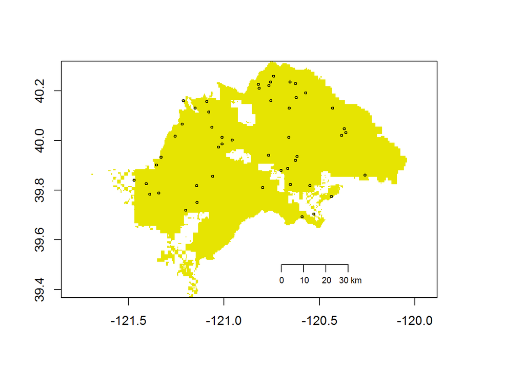

# Results of species prescence

## Here is a key for bat species

- *Myotis yumanensis* (Myyu)
- *Myotis californicus* (Myca)
- *Myotis ciliolabrum* (Myci)
- *Myotis volans* (Myvo)
- *Myotis lucifugus* (Mylu)
- *Parastrellus hesperus* (Pahe)
- *Lasiurus blossevillii* (Labo)
- *Myotis evotis* (Myev)
- *Antrozous pallidus* **(Anpa)**
- *Eptesicus fuscus* (Epfu)
- *Lasionycteris noctivagans* (Lano)
- *Myotis thysanodes* **(Myth)**
- *Tadarida brasiliensis* (Tabr)
- *Lasiurus cinereus* (Laci)
- *Corynorhinus townsendii* **(Coto)**
- *Euderma maculatum* (Euma)
- *Eumops perotis* (Eupe)

# Maps predicting the distribution of bats

## Yuma myotis (*Myotis yumanensis*)

[output not shown]

[output cut: 53 more lines]

[output not shown]

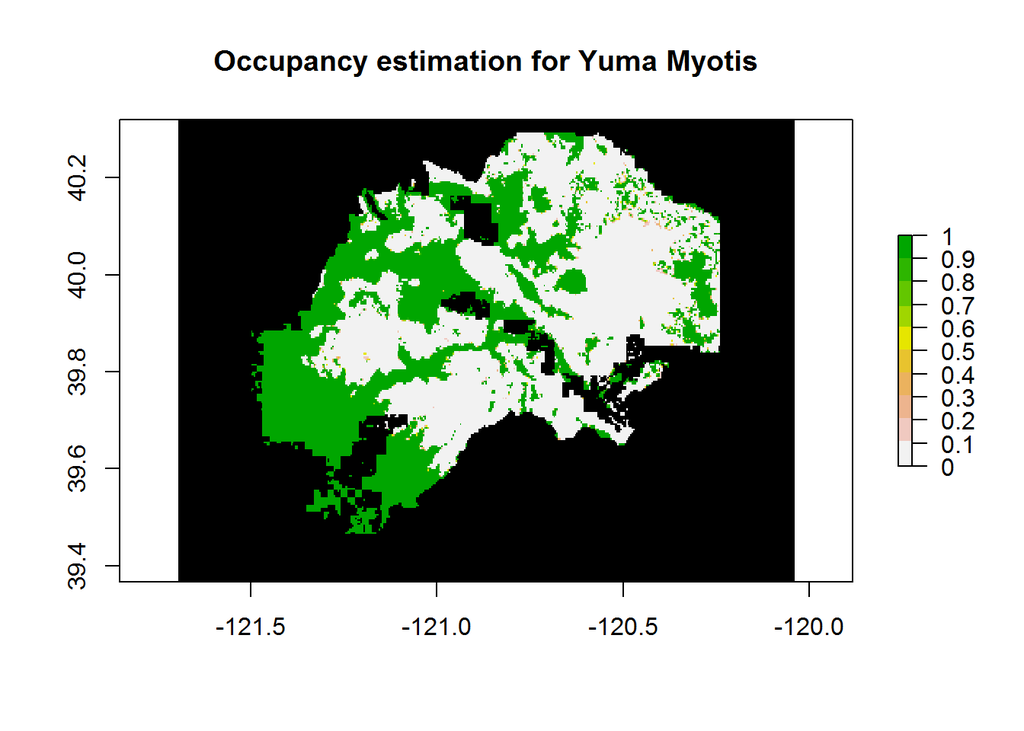

Statistical models

|  | **Model 1** | **Model 2** | **Model 3** | **Model 4** | **Model 5** | **Model 6** | **Model 7** | **Model 8** | **Model 9** | **Model 10** |
| --- | --- | --- | --- | --- | --- | --- | --- | --- | --- | --- |
| psi(Int) | -31.48 | -15.96 | -25.02 | -41.94 | -7.22 | -26.60 | -4.59 | -43.27 | -33.37 | -53.72 |
|  | (26.13) | (15.83) | (16.05) | (49.13) | (12.76) | (25.42) | (14.26) | (54.81) | (70.78) | (135.85) |
| psi(Altitude) | -85.49 | -118.75 | -173.73 | -112.02 | -56.97 | -35.12 | -34.80 | -115.35 | -130.98 | -398.03 |
|  | (70.86) | (104.47) | (111.71) | (126.11) | (85.45) | (35.86) | (30.58) | (135.11) | (114.23) | (2349.04) |
| psi(I(Altitude^2)) | 71.00 | 85.44 | 128.39 | 93.54 | 42.18 | 72.70 | 57.73 | 95.64 | 96.79 | 287.17 |
|  | (60.19) | (76.34) | (80.95) | (108.20) | (59.80) | (69.92) | (48.69) | (111.40) | (88.27) | (1560.20) |
| psi(Burn.intensity.Canopy) | -8.43 |  |  | -11.22 |  |  |  | -11.99 |  |  |
|  | (8.35) |  |  | (18.03) |  |  |  | (21.37) |  |  |
| psi(I(Burn.intensity.Canopy^2)) | 13.55 |  |  | 18.09 |  | 52.64 | 40.38 | 19.05 | 10.00 |  |
|  | (11.76) |  |  | (25.21) |  | (56.62) | (34.33) | (30.19) | (16.68) |  |
| psi(Existing.vegetation) | 19.94 | 23.15 | 33.41 | 26.24 | 13.04 | 58.30 | 52.39 | 27.26 | 23.76 | 76.66 |
|  | (16.63) | (19.81) | (20.50) | (31.37) | (14.15) | (58.38) | (45.19) | (35.76) | (45.61) | (537.16) |
| psi(Fire_edge) | -23.73 | -42.62 | -60.16 | -30.92 | -18.42 |  |  | -31.53 | -50.78 | -143.72 |
|  | (21.31) | (38.45) | (41.38) | (36.03) | (35.61) |  |  | (37.16) | (67.21) | (1021.02) |
| p(Int) | -1.10*** | -1.31*** | -1.22*** | -1.22*** | -1.42*** | -1.02*** | -1.25*** | -1.11*** | -1.12*** | -1.36*** |
|  | (0.31) | (0.30) | (0.30) | (0.29) | (0.30) | (0.30) | (0.29) | (0.31) | (0.30) | (0.32) |
| p(Meanhum) | 0.72* | 0.55 | 0.63 |  |  | 0.35 |  | 0.83* | 0.74* | 0.63 |
|  | (0.36) | (0.33) | (0.34) |  |  | (0.30) |  | (0.39) | (0.35) | (0.36) |
| psi(I(Distance.to.water^2)) |  |  | -3.42 |  |  |  |  |  |  |  |
|  |  |  | (2.35) |  |  |  |  |  |  |  |
| psi(Distance.to.road) |  |  |  |  |  | -18.86 |  |  | -8.96 |  |
|  |  |  |  |  |  | (22.55) |  |  | (10.81) |  |
| psi(I(Distance.to.road^2)) |  |  |  |  |  | 30.89 | 10.45 |  |  |  |
|  |  |  |  |  |  | (33.22) | (29.55) |  |  |  |
| psi(I(Existing.vegetation^2)) |  |  |  |  |  | -81.28 | -66.38 |  |  |  |
|  |  |  |  |  |  | (79.58) | (56.76) |  |  |  |
| p(Julian) |  |  |  |  |  |  |  | 0.36 |  |  |
|  |  |  |  |  |  |  |  | (0.33) |  |  |
| p(Meantemp) |  |  |  |  |  |  |  |  |  | 0.20 |
|  |  |  |  |  |  |  |  |  |  | (0.33) |
| Log Likelihood | -33.35 | -36.46 | -35.33 | -35.41 | -38.40 | -32.54 | -35.71 | -32.63 | -34.22 | -35.85 |
| AICc | 89.31 | 89.66 | 90.25 | 90.42 | 90.80 | 90.88 | 91.02 | 91.05 | 91.06 | 91.30 |
| Delta | 0.00 | 0.35 | 0.94 | 1.10 | 1.48 | 1.56 | 1.71 | 1.74 | 1.75 | 1.98 |
| Weight | 0.18 | 0.15 | 0.11 | 0.10 | 0.08 | 0.08 | 0.08 | 0.07 | 0.07 | 0.07 |
| Num. obs. | 49 | 49 | 49 | 49 | 49 | 49 | 49 | 49 | 49 | 49 |
| p < 0.001, p < 0.01, p < 0.05 |  |  |  |  |  |  |  |  |  |  |

## California bat (*Myotis californicus*)

### Total model

[output not shown]

[output cut: 53 more lines]

[output not shown]

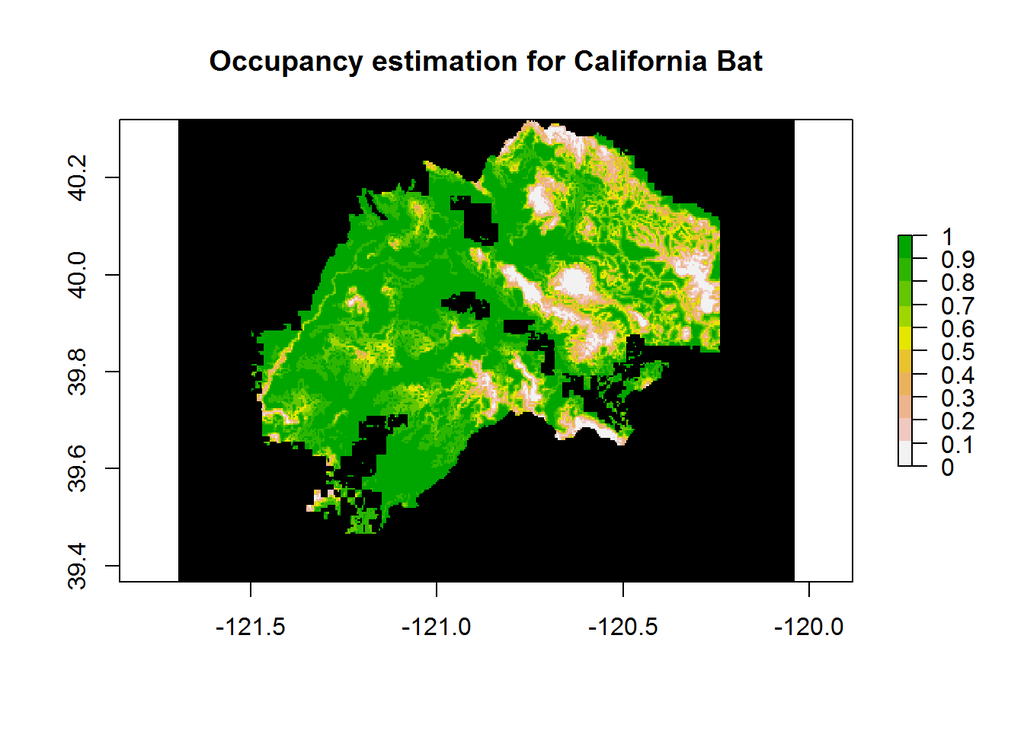

Statistical models

|  | **Model 1** | **Model 2** | **Model 3** | **Model 4** | **Model 5** | **Model 6** | **Model 7** | **Model 8** | **Model 9** | **Model 10** | **Model 11** | **Model 12** |
| --- | --- | --- | --- | --- | --- | --- | --- | --- | --- | --- | --- | --- |
| psi(Int) | 2.52** | 2.17** | 2.15** | 2.50** | 3.79** | 2.16* | 2.15*** | 3.98* | 2.16*** | 2.41* | 2.45** | 2.15* |
|  | (0.86) | (0.67) | (0.66) | (0.86) | (1.41) | (0.96) | (0.64) | (1.61) | (0.64) | (1.10) | (0.81) | (0.95) |
| psi(Altitude) | -1.54** | -1.51** | -1.50** | -1.52** | -1.58** | -2.39* | -1.47** | -1.57** | -1.45** | -2.32* | -1.51** | -2.38* |
|  | (0.54) | (0.51) | (0.51) | (0.54) | (0.53) | (1.06) | (0.50) | (0.53) | (0.50) | (1.10) | (0.53) | (1.06) |
| psi(I(Altitude^2)) | -0.81* | -0.85* | -0.84* | -0.80* | -1.08** |  | -0.83* | -1.09** | -0.83* |  | -0.79* |  |
|  | (0.33) | (0.33) | (0.33) | (0.33) | (0.39) |  | (0.32) | (0.40) | (0.32) |  | (0.33) |  |
| psi(Distance.to.road) | 1.41 |  |  | 1.40 |  |  |  |  |  | 1.29 | 1.27 |  |
|  | (1.09) |  |  | (1.10) |  |  |  |  |  | (1.07) | (1.08) |  |
| p(Int) | 0.98*** | 0.98*** | 1.04*** | 1.04*** | 1.00*** | 0.84*** | 1.00*** | 1.06*** | 1.06*** | 0.85*** | 0.99*** | 0.89*** |
|  | (0.25) | (0.25) | (0.26) | (0.26) | (0.24) | (0.24) | (0.25) | (0.26) | (0.26) | (0.25) | (0.25) | (0.25) |
| p(Meanhum) | -0.57* | -0.55* | -0.63* | -0.65* | -0.55* | -0.52* | -0.55* | -0.64* | -0.64* | -0.54* | -0.57* | -0.59* |
|  | (0.24) | (0.24) | (0.25) | (0.25) | (0.24) | (0.23) | (0.24) | (0.25) | (0.25) | (0.23) | (0.24) | (0.24) |
| p(sdhum) |  |  | -0.36 | -0.36 |  |  |  | -0.39 | -0.38 |  |  | -0.31 |
|  |  |  | (0.24) | (0.24) |  |  |  | (0.24) | (0.24) |  |  | (0.23) |
| psi(Burn.intensity.Canopy) |  |  |  |  | 1.58 |  | 0.54 | 1.71 | 0.58 |  | 0.45 |  |
|  |  |  |  |  | (0.89) |  | (0.48) | (1.01) | (0.50) |  | (0.48) |  |
| psi(I(Burn.intensity.Canopy^2)) |  |  |  |  | -1.27 |  |  | -1.39 |  |  |  |  |
|  |  |  |  |  | (0.84) |  |  | (0.96) |  |  |  |  |
| Log Likelihood | -77.07 | -78.37 | -77.23 | -75.93 | -76.15 | -80.19 | -77.65 | -74.86 | -76.42 | -79.19 | -76.59 | -79.29 |
| AICc | 168.13 | 168.14 | 168.46 | 168.60 | 169.02 | 169.29 | 169.30 | 169.31 | 169.58 | 169.78 | 169.91 | 169.98 |
| Delta | 0.00 | 0.01 | 0.33 | 0.47 | 0.89 | 1.15 | 1.17 | 1.18 | 1.45 | 1.65 | 1.78 | 1.85 |
| Weight | 0.13 | 0.13 | 0.11 | 0.10 | 0.08 | 0.07 | 0.07 | 0.07 | 0.06 | 0.06 | 0.05 | 0.05 |
| Num. obs. | 49 | 49 | 49 | 49 | 49 | 49 | 49 | 49 | 49 | 49 | 49 | 49 |
| p < 0.001, p < 0.01, p < 0.05 |  |  |  |  |  |  |  |  |  |  |  |  |

## Western Small Footed Myotis (*Myotis ciliolabrum*)

[output not shown]

[output cut: 53 more lines]

[output not shown]

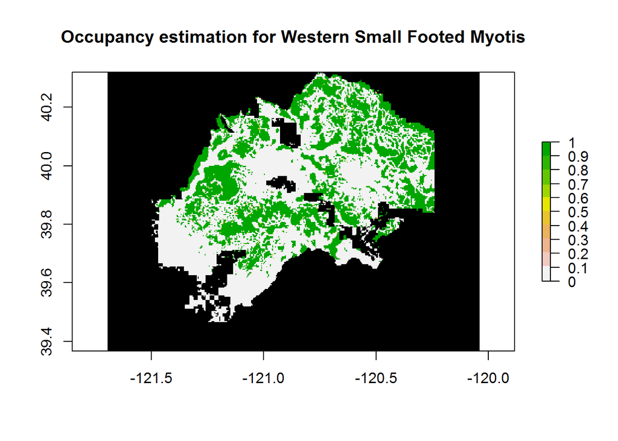

Statistical models

|  | **Model 1** | **Model 2** | **Model 3** | **Model 4** |
| --- | --- | --- | --- | --- |
| psi(Int) | 1.20 | 3.50 | 1.70 | 0.18 |
|  | (3.46) | (7.05) | (4.03) | (46.07) |
| psi(Altitude) | 70.25 | 158.23 | 97.64 |  |
|  | (67.03) | (186.46) | (90.46) |  |
| psi(I(Altitude^2)) | -74.07 | -171.03 | -104.99 |  |
|  | (73.85) | (204.33) | (100.42) |  |
| psi(Distance.to.road) | 141.25 | 323.80 | 198.89 | 68.95 |
|  | (137.87) | (384.56) | (187.72) | (304.75) |
| psi(Existing.vegetation) | -46.92 | -104.77 | -65.53 | -14.58 |
|  | (44.32) | (120.64) | (60.33) | (114.04) |
| psi(Fire_edge) | -71.82 | -165.49 | -101.77 | -49.45 |
|  | (70.87) | (197.26) | (96.92) | (253.48) |
| p(Int) | -0.72* | -0.73* | -0.77* | -1.19*** |
|  | (0.30) | (0.30) | (0.31) | (0.33) |
| p(Meanhum) |  | 0.16 |  |  |
|  |  | (0.29) |  |  |
| p(Julian) |  |  | 0.35 |  |
|  |  |  | (0.38) |  |
| p(Meantemp) |  |  |  | -0.53 |
|  |  |  |  | (0.34) |
| Log Likelihood | -33.56 | -32.82 | -32.86 | -35.84 |
| AICc | 83.86 | 85.24 | 85.31 | 85.67 |
| Delta | 0.00 | 1.38 | 1.45 | 1.81 |
| Weight | 0.42 | 0.21 | 0.20 | 0.17 |
| Num. obs. | 49 | 49 | 49 | 49 |
| p < 0.001, p < 0.01, p < 0.05 |  |  |  |  |

## Hairy-winged bat (*Myotis volans*)

[output not shown]

[output cut: 53 more lines]

[output not shown]

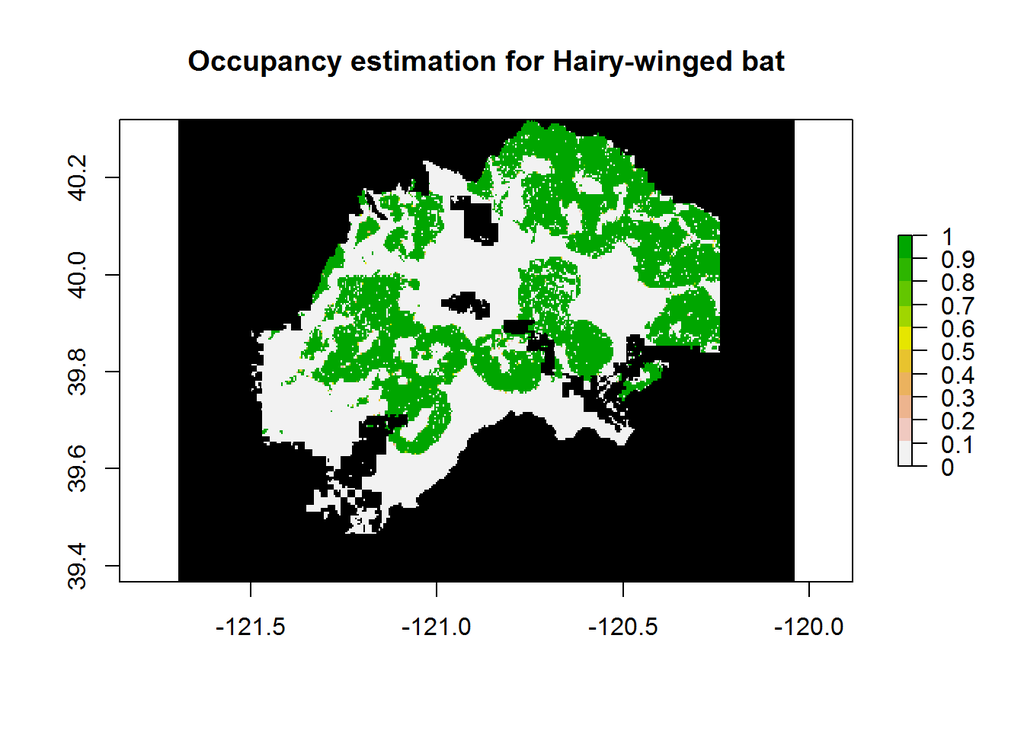

Statistical models

|  | **Model 1** | **Model 2** | **Model 3** |
| --- | --- | --- | --- |
| psi(Int) | -29.11 | 34.51 | -29.03 |
|  | (16256.16) | (62.86) |  |
| psi(Altitude) | 68.38 | 45.19 | 73.19 |
|  | (51.29) | (32.60) | (58.06) |
| psi(I(Distance.to.road^2)) | 18.52 | 10.82 | 19.56 |
|  | (18.88) | (10.97) | (21.67) |
| psi(Distance.to.water) | -165.92 |  | -172.40 |
|  | (37183.30) |  |  |
| psi(Existing.vegetation) | -23.23 | -15.63 | -24.92 |
|  | (17.16) | (11.00) | (19.52) |
| psi(I(Fire_edge^2)) | -163.49 | -108.71 | -174.28 |
|  | (121.77) | (77.51) | (137.29) |
| p(Int) | -0.52 | -0.53 | -0.73* |
|  | (0.33) | (0.33) | (0.31) |
| p(Meantemp) | 0.74* | 0.75* |  |
|  | (0.36) | (0.36) |  |
| psi(I(Distance.to.water^2)) |  | -24.71 |  |
|  |  | (305.09) |  |
| Log Likelihood | -28.82 | -29.18 | -31.12 |
| AICc | 77.25 | 77.96 | 78.97 |
| Delta | 0.00 | 0.71 | 1.72 |
| Weight | 0.47 | 0.33 | 0.20 |
| Num. obs. | 49 | 49 | 49 |
| p < 0.001, p < 0.01, p < 0.05 |  |  |  |

## Little Brown bat (*Myotis lucifugus*)

[output not shown]

[output cut: 53 more lines]

[output not shown]

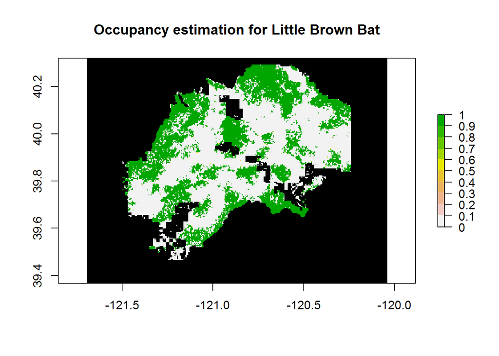

Statistical models

|  | **Model 1** | **Model 2** | **Model 3** | **Model 4** | **Model 5** | **Model 6** | **Model 7** | **Model 8** | **Model 9** | **Model 10** | **Model 11** | **Model 12** | **Model 13** | **Model 14** | **Model 15** | **Model 16** | **Model 17** | **Model 18** | **Model 19** | **Model 20** | **Model 21** | **Model 22** | **Model 23** | **Model 24** | **Model 25** | **Model 26** | **Model 27** | **Model 28** | **Model 29** |
| --- | --- | --- | --- | --- | --- | --- | --- | --- | --- | --- | --- | --- | --- | --- | --- | --- | --- | --- | --- | --- | --- | --- | --- | --- | --- | --- | --- | --- | --- |
| psi(Int) | -79.44 | 41.07 | 82.51 | 14.60 | -29.68 | -4.50 | -21.26 | 3.05 | 0.00 | 3.86 | 0.70 | 116.09 | 58.80 | -8.21 | -44.08 | 40.15 | -13.13 | 25.24 | -0.60 | -87.31 | -9.30 | 2.20 | -0.59 | 2.82 | -0.20 | 61.07 | 7.59 | 16.92 | 33.73 |
|  |  | (2564.25) |  |  | (37.11) | (747.96) | (264.67) | (286.23) | (10.01) | (1031.34) | (7.13) |  |  | (25.99) |  |  | (18.77) | (120.46) | (153.71) | (109.28) | (17.69) | (871.68) | (7.52) | (1863.84) | (8.95) | (2724.80) |  | (19.54) | (380.25) |
| psi(I(Altitude^2)) | -6.61 |  |  |  |  |  |  |  |  |  |  | -7.73 | -7.79 |  |  |  |  |  |  | -7.03 |  |  |  |  |  | -5.56 |  |  | -9.20 |
|  | (114.34) |  |  |  |  |  |  |  |  |  |  | (29.98) | (61.61) |  |  |  |  |  |  | (9.53) |  |  |  |  |  | (7.57) |  |  | (2215.18) |
| psi(Burn.intensity.Canopy) | 236.52 | 94.21 | 84.28 | 110.98 | 86.09 | 82.79 | 59.53 | 2.39** | 2.39** | 2.91* | 2.91* | 111.19 | 106.63 | 47.75 | 358.59 | 369.77 | 85.40 | 68.84 | 58.32 | 277.14 | 42.57 | 2.06* | 2.07* | 2.50* | 2.50* | 68.37 | 127.43 | 69.92 | 76.73 |
|  | (6240.41) | (945.49) | (84.56) | (2746.20) | (101.61) | (470.76) | (43.49) | (0.90) | (0.90) | (1.18) | (1.18) | (202.34) | (746.51) | (47.41) |  |  | (93.13) | (167.71) | (122.10) | (328.41) | (50.93) | (0.81) | (0.81) | (1.02) | (1.02) | (110.23) | (111.25) | (52.98) | (6729.71) |
| psi(I(Distance.to.road^2)) | 14.84 |  |  | 5.07 | 12.49 | 6.18 | 3.28 |  |  |  |  |  |  | 8.86 | 56.95 | 45.00 | 48.11 | 4.52 | 3.74 | 16.52 |  | 0.58 | 0.59 | 0.59 | 0.59 | 3.73 | 18.06 |  | 12.11 |
|  | (2260.56) |  |  | (65.20) | (13.85) | (137.23) | (5.78) |  |  |  |  |  |  | (11.88) |  |  | (68.32) | (13.42) | (7.10) | (20.09) |  | (0.54) | (0.54) | (0.59) | (0.59) | (179.73) | (15.18) |  | (7067.66) |
| psi(Distance.to.water) | -118.47 | -81.71 |  |  | -46.68 | -52.81 | -30.60 |  | -4.92 |  | -4.90 |  | -89.14 |  |  |  |  |  | -38.49 | -128.73 | -34.95 |  | -4.24 |  | -4.52 |  |  | -51.21 | -52.36 |
|  |  | (5638.86) |  |  | (52.59) | (1459.07) | (604.45) |  | (22.83) |  | (16.11) |  |  |  |  |  |  |  | (326.35) | (152.27) | (31.88) |  | (17.12) |  | (20.35) |  |  | (38.80) | (3977.59) |
| psi(Existing.vegetation) | -181.03 | -32.53 | -26.65 | -56.27 | -66.60 | -60.34 | -36.15 |  |  |  |  | -27.77 | -24.65 | -35.40 | -283.77 | -267.50 | -61.55 | -49.94 | -41.98 | -210.79 | -24.12 |  |  |  |  | -15.77 | -99.52 | -48.70 | -18.04 |
|  | (4614.82) | (189.02) | (24.48) | (573.41) | (80.76) | (401.13) | (27.93) |  |  |  |  | (246.23) | (50.07) | (34.70) |  |  | (68.01) | (140.16) | (85.70) | (252.52) | (20.70) |  |  |  |  | (22.22) | (88.41) | (39.60) | (1530.14) |
| psi(Fire_edge) | -117.39 | -13.18 | -10.49 | -50.61 | -69.57 | -43.34 | -34.18 |  |  |  |  |  |  | -37.84 | -293.31 | -277.35 | -33.75 | -31.29 | -28.55 | -134.91 | -27.63 |  |  |  |  |  | -104.15 | -24.23 |  |
|  | (2487.22) | (99.96) | (10.01) | (316.78) | (84.76) | (431.95) | (27.00) |  |  |  |  |  |  | (36.48) |  |  | (38.92) | (130.91) | (96.53) | (162.75) | (39.88) |  |  |  |  |  | (92.89) | (20.36) |  |
| psi(I(Fire_edge^2)) | 95.38 |  |  | 30.65 | 51.91 | 32.24 | 26.48 |  |  |  |  |  |  | 27.70 | 224.70 | 187.37 | 30.22 | 20.84 | 20.62 | 110.20 | 19.03 |  |  |  |  |  | 77.20 | 17.92 |  |
|  | (2235.10) |  |  | (622.54) | (62.04) | (374.44) | (20.70) |  |  |  |  |  |  | (27.69) |  |  | (34.03) | (117.65) | (97.23) | (132.37) | (22.71) |  |  |  |  |  | (68.02) | (14.43) |  |
| p(Int) | 0.31 | 0.26 | 0.25 | 0.36 | 0.71* | 0.43 | 0.36 | 1.20** | 1.20** | 1.01* | 1.01* | 0.26 | 0.26 | 0.71* | 0.71* | 0.72* | 0.19 | 0.23 | 0.23 | 0.24 | 0.33 | 1.20** | 1.20** | 1.01* | 1.01* | 0.26 | 0.72* | 0.23 | 0.26 |
|  | (0.28) | (0.27) | (0.27) | (0.29) | (0.30) | (0.30) | (0.29) | (0.41) | (0.41) | (0.40) | (0.40) | (0.27) | (0.27) | (0.30) | (0.30) | (0.31) | (0.27) | (0.27) | (0.27) | (0.27) | (0.27) | (0.41) | (0.41) | (0.41) | (0.41) | (0.27) | (0.30) | (0.27) | (0.27) |
| p(Julian) | -0.85** | -0.84** | -0.83** | -0.73* |  | -0.78** | -0.73* |  |  | -0.74 | -0.75 | -0.84** | -0.84** |  |  |  | -0.86** | -0.80** | -0.80** | -0.86** | -0.74* |  |  | -0.75 | -0.75 | -0.84** |  | -0.80** | -0.84** |
|  | (0.29) | (0.28) | (0.28) | (0.30) |  | (0.29) | (0.30) |  |  | (0.39) | (0.39) | (0.28) | (0.28) |  |  |  | (0.29) | (0.29) | (0.29) | (0.29) | (0.29) |  |  | (0.39) | (0.39) | (0.28) |  | (0.29) | (0.28) |
| p(Meantemp) | 0.42 |  |  | 0.61* | 0.79* | 0.61* | 0.60* | 0.93* | 0.93* | 0.96* | 0.96* |  |  | 0.79** | 0.79** | 0.89* |  |  |  |  |  | 0.94* | 0.94* | 0.99* | 0.99* |  | 0.77* |  |  |
|  | (0.30) |  |  | (0.30) | (0.31) | (0.30) | (0.30) | (0.43) | (0.43) | (0.45) | (0.45) |  |  | (0.31) | (0.31) | (0.37) |  |  |  |  |  | (0.43) | (0.43) | (0.45) | (0.45) |  | (0.31) |  |  |
| psi(Altitude) |  | 41.37 | 36.31 | 40.17 | 37.49 | 21.93 | 15.37 | 1.48* | 1.48* | 1.71* | 1.71* | 32.30 | 31.36 | 22.70 | 146.53 | 173.44 | 6.13 | 18.14 | 14.30 |  | 22.09 | 1.32* | 1.32* | 1.52* | 1.52* | 18.98 | 54.40 | 18.79 | 25.63 |
|  |  | (326.62) | (35.89) | (1838.57) | (41.85) | (287.47) | (10.86) | (0.63) | (0.63) | (0.72) | (0.72) | (69.64) | (122.43) | (26.67) |  |  | (7.29) | (54.75) | (25.46) |  | (19.82) | (0.57) | (0.57) | (0.65) | (0.65) | (33.67) | (45.83) | (17.31) | (4239.86) |
| psi(I(Burn.intensity.Canopy^2)) |  | -84.43 | -73.40 |  | -47.74 | -49.50 |  | -2.18* | -2.18* | -2.66* | -2.66* | -100.72 | -95.07 | -27.63 | -191.34 | -192.73 |  | -40.59 | -35.10 |  | -34.92 | -1.76* | -1.76* | -2.09* | -2.09* | -56.86 | -70.11 | -49.07 | -63.18 |
|  |  | (105.15) | (72.42) |  | (55.05) | (320.26) |  | (0.89) | (0.89) | (1.19) | (1.19) | (115.88) | (259.56) | (27.56) |  |  |  | (96.96) | (88.72) |  | (38.31) | (0.77) | (0.77) | (0.99) | (0.99) | (88.72) | (60.31) | (36.87) | (5375.43) |
| psi(Distance.to.road) |  | 27.36 | 15.50 |  |  |  |  | 1.12 | 1.12 | 1.18 | 1.18 | 23.43 | 15.84 |  | -16.80 |  |  |  |  |  | 18.81 |  |  |  |  |  |  | 19.52 |  |
|  |  | (2014.53) | (24.61) |  |  |  |  | (0.67) | (0.67) | (0.74) | (0.74) | (216.95) | (2388.73) |  |  |  |  |  |  |  | (14.84) |  |  |  |  |  |  | (15.71) |  |
| psi(I(Existing.vegetation^2)) |  | 33.84 | 26.98 |  |  |  |  |  |  |  |  | 33.83 | 33.47 | 10.45 |  |  |  |  |  |  | 22.59 |  |  |  |  | 20.37 |  |  | 24.17 |
|  |  | (177.37) | (23.71) |  |  |  |  |  |  |  |  | (179.55) | (80.12) | (16.07) |  |  |  |  |  |  | (29.17) |  |  |  |  | (36.42) |  |  | (2445.93) |
| psi(I(Distance.to.water^2)) |  |  | -88.89 | -46.95 |  |  |  | -4.72 |  | -5.37 |  | -52.29 |  | -16.84 | -99.81 | -259.15 | -21.97 | -25.09 |  |  |  | -4.94 |  | -5.46 |  | -30.15 | -119.29 |  |  |
|  |  |  |  |  |  |  |  | (1497.50) |  | (5395.76) |  |  |  | (73.84) |  |  | (23.07) | (159.41) |  |  |  | (4560.43) |  | (9751.24) |  | (14251.54) |  |  |  |
| p(sdtemp) |  |  |  |  |  |  |  | 0.85* | 0.85* | 0.73 | 0.73 |  |  |  |  |  |  |  |  |  |  | 0.84* | 0.84* | 0.73 | 0.73 |  |  |  |  |
|  |  |  |  |  |  |  |  | (0.40) | (0.40) | (0.43) | (0.43) |  |  |  |  |  |  |  |  |  |  | (0.40) | (0.40) | (0.42) | (0.42) |  |  |  |  |
| p(Meanhum) |  |  |  |  |  |  |  |  |  |  |  |  |  |  |  | 0.14 |  |  |  | -0.15 |  |  |  |  |  |  |  |  |  |
|  |  |  |  |  |  |  |  |  |  |  |  |  |  |  |  | (0.30) |  |  |  | (0.25) |  |  |  |  |  |  |  |  |  |
| p(sdhum) |  |  |  |  |  |  |  |  |  |  |  |  |  |  |  |  |  |  |  |  |  |  |  |  |  |  | -0.29 |  |  |
|  |  |  |  |  |  |  |  |  |  |  |  |  |  |  |  |  |  |  |  |  |  |  |  |  |  |  | (0.28) |  |  |
| Log Likelihood | -39.78 | -39.87 | -39.94 | -39.95 | -40.10 | -38.34 | -40.22 | -43.53 | -43.53 | -41.98 | -41.98 | -40.33 | -40.36 | -38.60 | -38.63 | -38.77 | -42.22 | -40.57 | -40.58 | -40.59 | -38.85 | -43.90 | -43.90 | -42.36 | -42.36 | -40.72 | -38.99 | -40.75 | -40.77 |
| AICc | 108.70 | 108.87 | 109.01 | 109.04 | 109.33 | 109.35 | 109.57 | 109.68 | 109.68 | 109.74 | 109.74 | 109.79 | 109.86 | 109.86 | 109.93 | 110.21 | 110.22 | 110.28 | 110.30 | 110.32 | 110.37 | 110.41 | 110.42 | 110.51 | 110.51 | 110.58 | 110.64 | 110.64 | 110.68 |
| Delta | 0.00 | 0.17 | 0.32 | 0.34 | 0.63 | 0.65 | 0.87 | 0.99 | 0.99 | 1.04 | 1.05 | 1.09 | 1.16 | 1.17 | 1.23 | 1.51 | 1.52 | 1.58 | 1.61 | 1.63 | 1.67 | 1.72 | 1.72 | 1.81 | 1.81 | 1.88 | 1.95 | 1.95 | 1.99 |
| Weight | 0.06 | 0.06 | 0.05 | 0.05 | 0.04 | 0.04 | 0.04 | 0.04 | 0.04 | 0.04 | 0.04 | 0.04 | 0.03 | 0.03 | 0.03 | 0.03 | 0.03 | 0.03 | 0.03 | 0.03 | 0.03 | 0.03 | 0.03 | 0.02 | 0.02 | 0.02 | 0.02 | 0.02 | 0.02 |
| Num. obs. | 49 | 49 | 49 | 49 | 49 | 49 | 49 | 49 | 49 | 49 | 49 | 49 | 49 | 49 | 49 | 49 | 49 | 49 | 49 | 49 | 49 | 49 | 49 | 49 | 49 | 49 | 49 | 49 | 49 |
| p < 0.001, p < 0.01, p < 0.05 |  |  |  |  |  |  |  |  |  |  |  |  |  |  |  |  |  |  |  |  |  |  |  |  |  |  |  |  |  |

## Western Red Bat (*Lasiurus blossevillii*)

[output not shown]

[output cut: 53 more lines]

[output not shown]

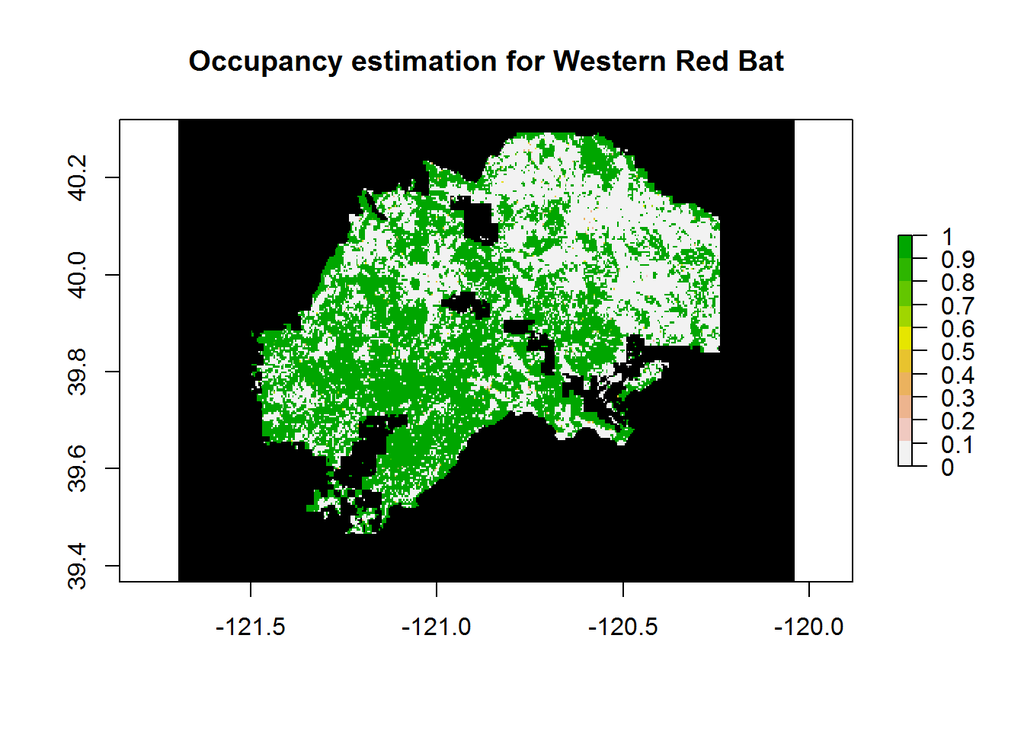

Statistical models

|  | **Model 1** | **Model 2** | **Model 3** | **Model 4** | **Model 5** |
| --- | --- | --- | --- | --- | --- |
| psi(Int) | -42.52 | -49.76 | -126.63 | -205.38 | -61.11 |
|  |  | (9893.30) |  | (16560.06) | (59.58) |
| psi(Altitude) | -35.57 | -21.76 | -58.08 |  |  |
|  | (44.75) | (19.40) |  |  |  |
| psi(Burn.intensity.Canopy) | -51.81 | -31.47 | -84.28 | -33.44 | -26.10 |
|  | (65.28) | (28.24) |  | (39.21) | (25.67) |
| psi(I(Distance.to.road^2)) | 21.89 | 13.35 | 114.10 | 112.05 | 35.23 |
|  | (27.69) | (11.98) |  | (131.94) | (34.42) |
| psi(I(Distance.to.water^2)) | -31.63 |  | -118.81 |  | -25.15 |
|  |  |  |  |  | (27.69) |
| psi(Existing.vegetation) | -122.08 | -73.95 | -199.46 | -94.57 | -98.32 |
|  | (154.18) | (66.70) |  | (109.07) | (95.07) |
| p(Int) | -1.25*** | -1.26*** | -1.18*** | -1.32*** | -1.19*** |
|  | (0.33) | (0.33) | (0.33) | (0.33) | (0.33) |
| psi(Distance.to.water) |  | -46.63 |  | -342.86 |  |
|  |  | (22629.33) |  | (37877.84) |  |
| psi(Distance.to.road) |  |  | -73.78 | -99.63 | -36.66 |
|  |  |  |  | (120.00) | (37.34) |
| psi(I(Altitude^2)) |  |  |  |  | 12.65 |
|  |  |  |  |  | (11.76) |
| Log Likelihood | -28.63 | -28.78 | -27.83 | -29.52 | -28.14 |
| AICc | 74.00 | 74.30 | 75.26 | 75.77 | 75.88 |
| Delta | 0.00 | 0.30 | 1.25 | 1.77 | 1.88 |
| Weight | 0.31 | 0.27 | 0.17 | 0.13 | 0.12 |
| Num. obs. | 49 | 49 | 49 | 49 | 49 |
| p < 0.001, p < 0.01, p < 0.05 |  |  |  |  |  |

## Long-eared Bat (*Myotis evotis*)

[output not shown]

[output cut: 53 more lines]

[output not shown]

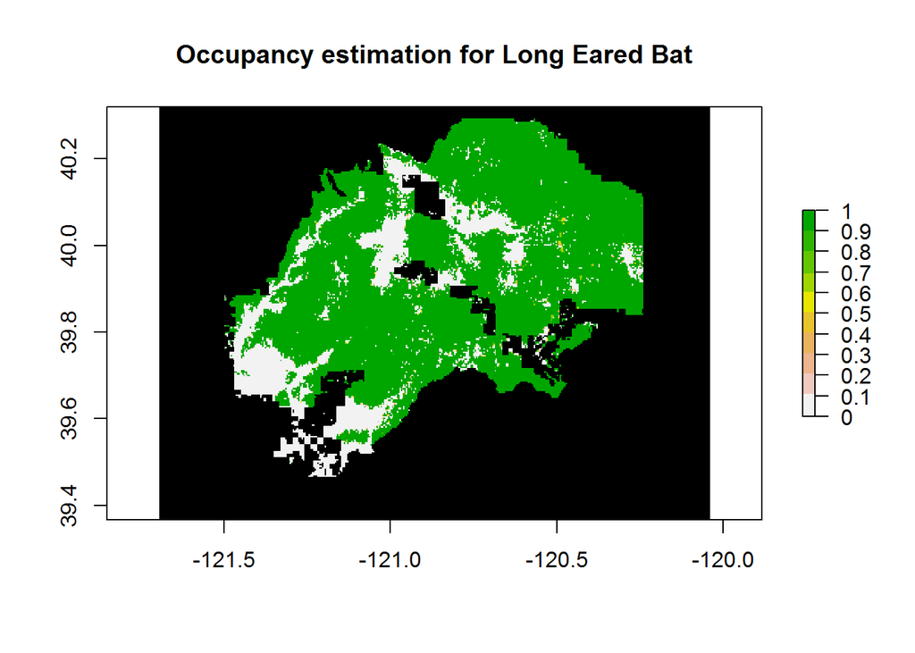

Statistical models

|  | **Model 1** | **Model 2** | **Model 3** | **Model 4** | **Model 5** | **Model 6** | **Model 7** | **Model 8** | **Model 9** | **Model 10** | **Model 11** | **Model 12** | **Model 13** | **Model 14** | **Model 15** | **Model 16** | **Model 17** | **Model 18** |
| --- | --- | --- | --- | --- | --- | --- | --- | --- | --- | --- | --- | --- | --- | --- | --- | --- | --- | --- |
| psi(Int) | 46.50 | 31.73 | 64.31 | 114.98 | 83.28 | 114.21 | 235.67 | 165.40 | 34.19 | 436.82 | 158.17 | 38.36 | 104.05 | 35.46 | 26.07 | 38.87 | 203.18 | 31.92 |
|  | (34.20) | (21.59) | (175.38) | (622.95) | (77.57) | (87.80) | (243.12) | (185.32) | (21.28) | (2633.37) | (1974.88) | (25.62) |  | (22.52) | (17.91) | (23.92) |  | (19.13) |
| psi(Altitude) | 40.55 | 27.79 | 56.43 | 74.44 | 51.49 | 38.23 | 107.72 | 95.66 | 21.43 | 151.53 | 43.71 | 33.51 | 30.36 | 30.79 | 16.53 | 24.20 | 79.58 | 27.89 |
|  | (29.51) | (18.91) | (161.00) | (450.86) | (47.44) | (30.52) | (115.87) | (458.48) | (13.47) | (1114.01) | (38.56) | (22.20) | (22.72) | (19.18) | (11.35) | (15.22) |  | (16.34) |
| psi(I(Altitude^2)) | -34.29 | -22.79 | -42.72 | -60.23 | -44.01 | -34.96 | -42.46 | -43.86 | -17.75 | -112.62 | -40.01 | -28.03 | -27.44 | -25.89 | -13.33 | -20.32 | -108.25 | -23.78 |
|  | (24.51) | (14.65) | (90.16) | (339.25) | (41.01) | (28.66) | (79.30) | (477.96) | (11.12) | (749.45) | (36.06) | (18.06) | (21.15) | (15.78) | (9.34) | (12.63) |  | (14.13) |
| psi(I(Burn.intensity.Canopy^2)) | 103.31 | 64.81 | 115.01 | 166.46 | 139.21 |  | 47.73 | 60.50 | 51.73 |  |  | 82.98 |  | 77.48 | 38.89 | 60.59 | 173.96 | 73.21 |
|  | (73.45) | (38.67) | (179.66) | (740.69) | (145.87) |  | (172.01) | (1162.58) | (31.96) |  |  | (51.26) |  | (46.85) | (27.38) | (36.62) |  | (44.40) |
| psi(Distance.to.water) | -34.65 | -22.94 | -43.27 |  |  | -16.30 |  | -48.69 |  |  | -18.59 | -28.36 |  | -26.30 |  |  |  | -24.21 |
|  | (24.08) | (14.13) | (94.86) |  |  | (13.61) |  | (114.47) |  |  | (16.98) | (17.56) |  | (15.53) |  |  |  | (13.83) |
| psi(I(Existing.vegetation^2)) | -27.92 | -18.36 | -38.24 | -44.44 | -35.78 |  | -90.72 | -81.26 | -14.12 |  |  | -22.67 |  | -21.04 | -10.28 | -15.96 |  | -19.19 |
|  | (21.38) | (13.14) | (107.29) | (130.42) | (34.12) |  | (98.95) | (427.67) | (9.90) |  |  | (15.77) |  | (14.13) | (8.34) | (10.51) |  | (12.43) |
| psi(Fire_edge) | -145.80 | -94.63 | -177.34 | -236.62 | -192.07 |  | -202.53 | -185.84 | -74.44 |  |  | -118.18 |  | -110.50 | -56.56 | -85.19 | -473.65 | -102.51 |
|  | (101.25) | (56.94) | (372.64) | (1091.11) | (191.95) |  | (241.24) | (1165.95) | (44.54) |  |  | (72.21) |  | (65.51) | (37.86) | (49.77) |  | (59.84) |
| psi(I(Fire_edge^2)) | 56.10 | 36.67 | 70.50 | 89.36 | 73.27 |  | 75.79 | 72.89 | 28.67 |  |  | 45.54 |  | 42.51 | 21.71 | 32.56 | 164.10 | 39.22 |
|  | (39.30) | (22.69) | (163.28) | (359.88) | (71.48) |  | (106.04) | (580.29) | (17.49) |  |  | (28.29) |  | (25.52) | (14.84) | (19.16) |  | (23.05) |
| p(Int) | 0.39* | 0.37 | 0.37 | 0.40* | 0.41* | 0.29 | 0.40* | 0.40* | 0.38* | 0.41* | 0.41* | 0.41* | 0.38* | 0.40* | 0.36 | 0.37 | 0.38* | 0.38* |
|  | (0.19) | (0.19) | (0.19) | (0.19) | (0.20) | (0.19) | (0.19) | (0.19) | (0.19) | (0.20) | (0.20) | (0.20) | (0.19) | (0.19) | (0.19) | (0.19) | (0.19) | (0.19) |
| p(sdtemp) | 0.31 |  |  |  | 0.36 |  |  |  | 0.31 | 0.33 | 0.33 | 0.36 |  |  |  |  |  |  |
|  | (0.21) |  |  |  | (0.21) |  |  |  | (0.21) | (0.20) | (0.20) | (0.21) |  |  |  |  |  |  |
| p(Meanhum) |  |  | -0.24 |  |  | -0.41* | -0.38* | -0.38* |  |  |  |  |  |  |  | -0.25 |  |  |
|  |  |  | (0.19) |  |  | (0.19) | (0.19) | (0.19) |  |  |  |  |  |  |  | (0.19) |  |  |
| psi(I(Distance.to.water^2)) |  |  |  | -33.65 | -25.16 |  | -32.01 |  | -10.00 | -22.05 |  |  | -7.03 |  | -7.73 | -11.50 | -61.79 |  |
|  |  |  |  | (190.48) | (24.38) |  | (31.80) |  | (5.95) | (121.02) |  |  | (5.53) |  | (5.06) | (6.87) |  |  |
| p(Meantemp) |  |  |  | 0.21 |  |  |  |  |  | 0.37 | 0.37 |  | 0.36 | 0.22 |  |  |  |  |
|  |  |  |  | (0.21) |  |  |  |  |  | (0.21) | (0.21) |  | (0.21) | (0.21) |  |  |  |  |
| p(Julian) |  |  |  |  | 0.27 |  |  |  |  |  |  | 0.27 |  |  |  |  | 0.20 | 0.18 |
|  |  |  |  |  | (0.20) |  |  |  |  |  |  | (0.20) |  |  |  |  | (0.19) | (0.19) |
| psi(Burn.intensity.Canopy) |  |  |  |  |  | 44.99 |  |  |  | 447.07 | 192.50 |  | 131.46 |  |  |  | -101.82 |  |
|  |  |  |  |  |  | (48.18) |  |  |  | (2698.74) | (209.02) |  | (71.56) |  |  |  |  |  |
| psi(Distance.to.road) |  |  |  |  |  | 80.19 |  |  |  | 304.76 | 101.85 |  | 113.03 |  |  |  |  |  |
|  |  |  |  |  |  | (73.41) |  |  |  |  | (6879.00) |  |  |  |  |  |  |  |
| psi(Existing.vegetation) |  |  |  |  |  |  | 61.39 | 46.93 |  |  |  |  |  |  |  |  |  |  |
|  |  |  |  |  |  |  | (88.09) | (50.15) |  |  |  |  |  |  |  |  |  |  |
| psi(I(Distance.to.road^2)) |  |  |  |  |  |  |  |  |  | 526.94 | 278.63 |  | 295.74 |  |  |  |  |  |
|  |  |  |  |  |  |  |  |  |  |  | (17339.52) |  |  |  |  |  |  |  |
| Log Likelihood | -76.72 | -78.37 | -77.09 | -77.34 | -75.67 | -80.50 | -75.75 | -75.81 | -77.52 | -77.57 | -77.57 | -75.91 | -79.24 | -77.66 | -79.26 | -77.68 | -77.70 | -77.71 |
| AICc | 179.22 | 179.36 | 179.97 | 180.46 | 180.47 | 180.60 | 180.64 | 180.75 | 180.84 | 180.92 | 180.93 | 180.96 | 181.10 | 181.12 | 181.14 | 181.14 | 181.18 | 181.20 |
| Delta | 0.00 | 0.14 | 0.75 | 1.24 | 1.25 | 1.38 | 1.42 | 1.53 | 1.62 | 1.70 | 1.71 | 1.74 | 1.88 | 1.90 | 1.92 | 1.92 | 1.96 | 1.98 |
| Weight | 0.11 | 0.10 | 0.08 | 0.06 | 0.06 | 0.05 | 0.05 | 0.05 | 0.05 | 0.05 | 0.05 | 0.05 | 0.04 | 0.04 | 0.04 | 0.04 | 0.04 | 0.04 |
| Num. obs. | 49 | 49 | 49 | 49 | 49 | 49 | 49 | 49 | 49 | 49 | 49 | 49 | 49 | 49 | 49 | 49 | 49 | 49 |
| p < 0.001, p < 0.01, p < 0.05 |  |  |  |  |  |  |  |  |  |  |  |  |  |  |  |  |  |  |

## Pallid Bat (*Antrozous pallidus*)

[output not shown]

[output cut: 53 more lines]

[output not shown]

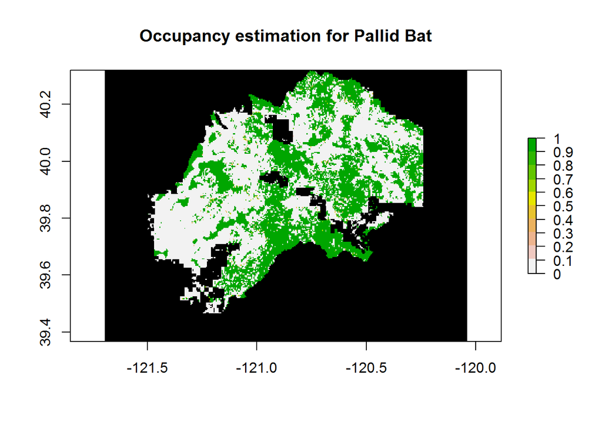

Statistical models

|  | **Model 1** | **Model 2** | **Model 3** | **Model 4** | **Model 5** | **Model 6** | **Model 7** | **Model 8** | **Model 9** | **Model 10** | **Model 11** | **Model 12** | **Model 13** |
| --- | --- | --- | --- | --- | --- | --- | --- | --- | --- | --- | --- | --- | --- |
| psi(Int) | -79.13 | -78.09 | -109.03 | -84.43 | -146.37 | -226.39 | -143.00 | -93.04 | -104.45 | -155.04 | -152.39 | -172.07 | -90.80 |
|  | (70.42) | (56.48) | (131.44) | (160.94) | (5494.97) |  | (21892.06) | (95.28) | (98.55) |  | (1399.29) |  | (95.92) |
| psi(Altitude) | 32.00 | 26.97 |  |  | 63.00 | 92.07 | 48.24 | 37.61 | 35.90 | 15.17 | 13.89 |  |  |
|  | (27.24) | (19.88) |  |  | (272.43) | (72.88) | (130.62) | (38.67) | (34.47) | (554.17) | (333.59) |  |  |
| psi(I(Distance.to.road^2)) | 52.79 | 44.27 |  |  | 38.81 | 54.26 | 30.22 | 61.98 | 59.22 |  |  |  |  |
|  | (45.30) | (32.83) |  |  | (679.26) | (42.53) | (327.36) | (63.41) | (56.91) |  |  |  |  |
| psi(I(Distance.to.water^2)) | -15.04 |  |  | -13.90 | -93.51 | -41.14 |  | -17.05 |  | -32.76 |  | -35.00 |  |
|  | (102.41) |  |  | (675.65) | (27511.49) |  |  | (72.91) |  |  |  |  |  |
| psi(Existing.vegetation) | -68.26 | -57.12 | -46.65 | -43.45 | -67.93 | -86.67 | -54.03 | -80.12 | -76.54 | -60.70 | -49.59 | -121.12 | -37.88 |
|  | (58.11) | (41.71) | (92.42) | (178.26) | (2776.36) | (69.23) | (1345.87) | (81.00) | (72.79) | (391.02) | (238.39) | (130.06) | (43.15) |
| psi(Fire_edge) | 41.87 | 35.01 |  |  |  |  |  | 49.13 | 46.97 |  |  |  |  |
|  | (35.57) | (25.44) |  |  |  |  |  | (49.66) | (44.77) |  |  |  |  |
| p(Int) | -0.43 | -0.43 | -0.57 | -0.59 | -0.24 | -0.32 | -0.27 | -0.49 | -0.49 | -0.45 | -0.45 | -0.61 | -0.74 |
|  | (0.36) | (0.36) | (0.38) | (0.38) | (0.37) | (0.39) | (0.37) | (0.37) | (0.37) | (0.38) | (0.38) | (0.37) | (0.42) |
| psi(Distance.to.water) |  | -21.56 | -23.74 |  |  |  | -34.37 |  | -28.31 |  | -35.82 |  | -25.34 |
|  |  | (18.89) | (37.12) |  |  |  | (49917.67) |  | (33.50) |  | (293.55) |  | (29.80) |
| psi(I(Altitude^2)) |  |  | 39.10 | 35.49 |  |  |  |  |  | 63.63 | 53.75 | 81.73 | 41.51 |
|  |  |  | (49.75) | (58.28) |  |  |  |  |  | (621.56) | (372.25) | (88.45) | (46.11) |
| psi(Burn.intensity.Canopy) |  |  | 10.53 | 9.36 | 28.64 | 41.38 | 22.28 |  |  | 25.28 | 21.64 | 25.89 | 14.70 |
|  |  |  | (21.71) | (40.23) | (103.91) | (32.63) | (50.12) |  |  | (307.36) | (183.67) | (29.24) | (16.24) |
| psi(I(Existing.vegetation^2)) |  |  | 36.05 | 28.14 | 74.65 | 117.05 | 57.87 |  |  | 65.07 | 57.32 |  | 16.68 |
|  |  |  | (132.09) | (266.48) | (932.75) | (93.40) | (465.97) |  |  | (2236.82) | (1339.57) |  | (28.11) |
| p(Meantemp) |  |  | -0.81* | -0.82* |  |  |  |  |  | -0.72 | -0.72 | -0.69 | -0.93* |
|  |  |  | (0.39) | (0.40) |  |  |  |  |  | (0.38) | (0.38) | (0.38) | (0.44) |
| p(Meanhum) |  |  |  |  |  | 0.51 |  | 0.41 | 0.40 |  |  |  |  |
|  |  |  |  |  |  | (0.37) |  | (0.35) | (0.35) |  |  |  |  |
| psi(I(Fire_edge^2)) |  |  |  |  |  |  |  |  |  |  |  | 17.46 |  |
|  |  |  |  |  |  |  |  |  |  |  |  | (18.75) |  |
| p(Julian) |  |  |  |  |  |  |  |  |  |  |  |  | -0.51 |
|  |  |  |  |  |  |  |  |  |  |  |  |  | (0.40) |
| Log Likelihood | -22.21 | -22.29 | -20.99 | -21.02 | -21.05 | -19.68 | -21.28 | -21.47 | -21.48 | -20.04 | -20.08 | -21.61 | -20.20 |
| AICc | 61.15 | 61.32 | 61.58 | 61.64 | 61.69 | 61.98 | 62.17 | 62.54 | 62.56 | 62.69 | 62.77 | 62.81 | 63.01 |
| Delta | 0.00 | 0.16 | 0.42 | 0.48 | 0.54 | 0.82 | 1.01 | 1.38 | 1.40 | 1.54 | 1.61 | 1.66 | 1.85 |
| Weight | 0.12 | 0.11 | 0.10 | 0.09 | 0.09 | 0.08 | 0.07 | 0.06 | 0.06 | 0.06 | 0.05 | 0.05 | 0.05 |
| Num. obs. | 49 | 49 | 49 | 49 | 49 | 49 | 49 | 49 | 49 | 49 | 49 | 49 | 49 |
| p < 0.001, p < 0.01, p < 0.05 |  |  |  |  |  |  |  |  |  |  |  |  |  |

### Fringed Bat (*Myotis thysanoides*)

[output not shown]

[output cut: 53 more lines]

[output not shown]

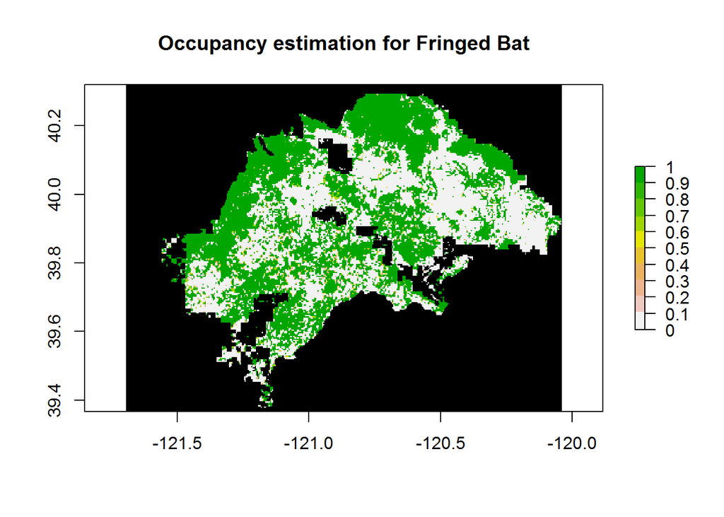

Statistical models

|  | **Model 1** | **Model 2** | **Model 3** | **Model 4** | **Model 5** | **Model 6** | **Model 7** | **Model 8** | **Model 9** | **Model 10** | **Model 11** | **Model 12** | **Model 13** | **Model 14** | **Model 15** | **Model 16** |
| --- | --- | --- | --- | --- | --- | --- | --- | --- | --- | --- | --- | --- | --- | --- | --- | --- |
| psi(Int) | 27.53 | 66.72 | 61.19 | 125.81 | 52.79 | 41.61 | 23.54 | 217.46 | 60.52 | 29.07 | 115.46 | 28.84 | 14.96 | 50.70 | 65.42 | 23.44 |
|  | (28.35) | (77.31) | (68.83) | (112.76) | (64.57) | (55.15) | (178.04) | (303.83) | (59.31) | (31.15) | (138.37) | (24.43) | (23.35) | (74.97) | (66.19) | (31.29) |
| psi(Burn.intensity.Canopy) | 49.50 |  | -18.96 | -47.02 | 85.24 | 74.55 |  | -37.46 |  | 75.04 | 148.57 | 50.32 | 34.27 | 71.98 | -19.98 |  |
|  | (50.44) |  | (20.96) | (43.70) | (104.72) | (97.52) |  | (58.69) |  | (81.98) | (181.46) | (43.06) | (48.25) | (116.82) | (20.43) |  |
| psi(Existing.vegetation) | -25.59 |  |  | 20.93 | -45.73 | -38.01 | -28.37 |  |  | -38.82 | -76.19 | -25.69 | -17.45 | -61.35 |  | -17.01 |
|  | (24.93) |  |  | (20.24) | (75.24) | (48.34) | (29.39) |  |  | (43.43) | (92.20) | (21.36) | (21.23) | (93.84) |  | (23.75) |
| p(Int) | -2.17*** | -1.81*** | -1.91*** | -1.80*** | -1.95*** | -2.16*** | -1.97*** | -1.90*** | -2.20*** | -2.09*** | -1.99*** | -2.05*** | -2.06*** | -2.12*** | -1.87*** | -1.99*** |
|  | (0.39) | (0.38) | (0.38) | (0.38) | (0.54) | (0.38) | (0.38) | (0.38) | (0.38) | (0.39) | (0.39) | (0.40) | (0.40) | (0.38) | (0.38) | (0.39) |
| p(Julian) | 1.08** | 0.85* | 0.98** | 0.99** | 1.02 | 1.10** | 1.06** | 0.91* | 1.02** | 1.02** | 1.03* | 0.97* | 0.97* | 1.03** | 0.95** | 1.07** |
|  | (0.40) | (0.38) | (0.36) | (0.36) | (0.60) | (0.39) | (0.40) | (0.37) | (0.37) | (0.39) | (0.41) | (0.41) | (0.41) | (0.39) | (0.36) | (0.40) |
| psi(I(Altitude^2)) |  | -31.16 | -21.74 | -32.30 | -32.67 |  | -61.46 | -18.46 | -17.14 |  | -71.85 | -10.07 |  |  | -22.94 | -33.98 |
|  |  | (40.87) | (24.11) | (31.80) | (57.61) |  | (78.26) | (33.03) | (16.79) |  | (86.18) | (10.28) |  |  | (23.38) | (46.69) |
| psi(I(Burn.intensity.Canopy^2)) |  | -19.13 |  |  |  |  |  |  |  |  |  |  |  | -37.40 |  |  |
|  |  | (23.16) |  |  |  |  |  |  |  |  |  |  |  | (63.13) |  |  |
| psi(Distance.to.road) |  | 44.56 | 18.40 | 28.52 |  |  |  |  |  | -21.77 | 40.26 |  |  |  | 18.67 |  |
|  |  | (56.80) | (22.55) | (29.33) |  |  |  |  |  | (22.40) | (49.18) |  |  |  | (21.64) |  |
| psi(I(Existing.vegetation^2)) |  | -22.97 | -32.84 | -88.79 |  |  |  | -197.32 | -33.39 |  |  |  |  |  | -35.28 |  |
|  |  | (26.53) | (38.87) | (79.55) |  |  |  | (269.80) | (33.47) |  |  |  |  |  | (36.98) |  |
| psi(Distance.to.water) |  |  |  |  | 5.11 |  |  |  |  |  |  |  |  |  |  | 16.43 |
|  |  |  |  |  | (25.43) |  |  |  |  |  |  |  |  |  |  | (23.28) |
| p(Meantemp) |  |  |  |  |  | 0.35 |  |  |  |  |  |  |  |  |  |  |
|  |  |  |  |  |  | (0.33) |  |  |  |  |  |  |  |  |  |  |
| psi(I(Distance.to.road^2)) |  |  |  |  |  |  | 26.68 |  |  |  |  |  |  |  |  | 14.19 |
|  |  |  |  |  |  |  |  |  |  |  |  |  |  |  |  | (18.72) |
| psi(I(Distance.to.water^2)) |  |  |  |  |  |  | 17.30 |  |  |  |  |  |  |  |  |  |
|  |  |  |  |  |  |  | (917.58) |  |  |  |  |  |  |  |  |  |
| psi(Altitude) |  |  |  |  |  |  |  | 28.49 |  |  |  |  | 13.96 |  |  |  |
|  |  |  |  |  |  |  |  | (38.79) |  |  |  |  | (16.60) |  |  |  |
| p(sdhum) |  |  |  |  |  |  |  |  |  |  |  |  |  |  | 0.59 |  |
|  |  |  |  |  |  |  |  |  |  |  |  |  |  |  | (0.44) |  |
| Log Likelihood | -33.72 | -31.08 | -31.51 | -30.13 | -31.62 | -33.02 | -31.74 | -31.77 | -34.44 | -33.16 | -31.85 | -33.27 | -33.27 | -33.30 | -30.54 | -32.00 |
| AICc | 78.83 | 78.90 | 79.76 | 79.86 | 79.97 | 80.05 | 80.20 | 80.26 | 80.27 | 80.33 | 80.43 | 80.54 | 80.55 | 80.61 | 80.68 | 80.74 |
| Delta | 0.00 | 0.07 | 0.93 | 1.03 | 1.14 | 1.22 | 1.37 | 1.43 | 1.45 | 1.50 | 1.61 | 1.71 | 1.72 | 1.78 | 1.85 | 1.91 |
| Weight | 0.11 | 0.11 | 0.07 | 0.07 | 0.06 | 0.06 | 0.06 | 0.06 | 0.06 | 0.05 | 0.05 | 0.05 | 0.05 | 0.05 | 0.05 | 0.04 |
| Num. obs. | 49 | 49 | 49 | 49 | 49 | 49 | 49 | 49 | 49 | 49 | 49 | 49 | 49 | 49 | 49 | 49 |
| p < 0.001, p < 0.01, p < 0.05 |  |  |  |  |  |  |  |  |  |  |  |  |  |  |  |  |

[output not shown]

[output cut: 53 more lines]

[output not shown]

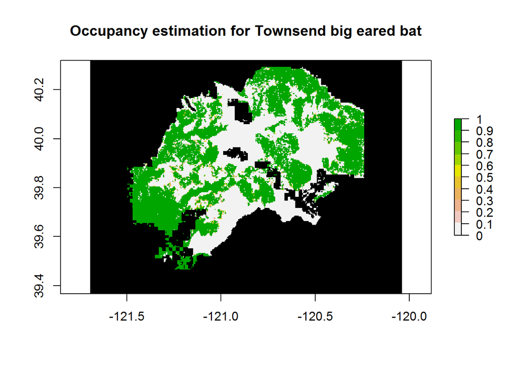

Statistical models

|  | **Model 1** | **Model 2** | **Model 3** | **Model 4** | **Model 5** | **Model 6** | **Model 7** | **Model 8** | **Model 9** | **Model 10** | **Model 11** | **Model 12** | **Model 13** | **Model 14** | **Model 15** | **Model 16** | **Model 17** | **Model 18** | **Model 19** | **Model 20** | **Model 21** | **Model 22** | **Model 23** | **Model 24** | **Model 25** | **Model 26** | **Model 27** | **Model 28** | **Model 29** | … |
| --- | --- | --- | --- | --- | --- | --- | --- | --- | --- | --- | --- | --- | --- | --- | --- | --- | --- | --- | --- | --- | --- | --- | --- | --- | --- | --- | --- | --- | --- | --- |
| psi(Int) | -12.01 | 0.01 | -1.99 | -2.67 | -0.40 | -0.11 | -2.71 | -1.53** | -0.23 | -2.99 | -0.06 | -2.30 | -1.70*** | -2.18 | -0.36 | -3.09 | -1.36* | -25.77 | -1.08 | -0.32 | -2.94 | -1.22 | -2.92 | -65.76 | -59.41 | -0.43 | -3.33 | -0.10 | -2.87 | … |
|  | (25.30) | (5.10) | (11.90) | (26.85) | (4.92) | (1559.19) | (15.43) | (0.59) |  | (21.09) | (17.61) | (17.51) | (0.49) | (3047.11) | (18.04) | (73.88) | (0.55) | (30.81) | (0.74) | (8512.29) | (21.96) | (2.39) | (7.87) | (93.06) |  | (6331.15) | (44.18) | (2022.32) | (23.40) | … |
| psi(I(Altitude^2)) | 64.88 |  |  | 0.47 | 0.47 |  |  |  |  |  |  |  |  |  | 0.43 | 0.43 |  | 44.99 |  |  |  | 0.37 | 0.37 | 33.59 | 430.59 |  |  |  |  | … |
|  | (67.43) |  |  | (0.39) | (0.39) |  |  |  |  |  |  |  |  |  | (0.32) | (0.32) |  | (51.69) |  |  |  | (0.32) | (0.32) | (46.69) |  |  |  |  |  | … |
| psi(I(Burn.intensity.Canopy^2)) | 10.80 |  |  |  |  |  |  |  |  |  |  |  |  |  |  |  |  | 46.40 |  |  |  |  |  | -27.89 |  |  |  |  |  | … |
|  | (18.72) |  |  |  |  |  |  |  |  |  |  |  |  |  |  |  |  | (50.37) |  |  |  |  |  | (39.20) |  |  |  |  |  | … |
| psi(I(Distance.to.water^2)) | -32.66 | -2.23 |  |  | -2.22 | -5.31 |  |  | -5.47 |  | -2.77 |  |  | -13.34 | -2.79 |  |  | -18.39 |  | -5.20 |  | -1.80 |  | -44.36 | -227.96 | -5.31 |  | -5.38 |  | … |
|  | (36.09) | (26.30) |  |  | (25.29) | (8157.35) |  |  |  |  | (92.04) |  |  | (15941.52) | (94.30) |  |  | (27.11) |  | (44534.55) |  | (11.98) |  | (63.65) |  | (33123.29) |  | (10580.37) |  | … |
| psi(Existing.vegetation) | -13.51 |  |  |  |  |  |  |  |  |  |  |  |  |  |  |  |  |  |  |  |  |  |  | -78.54 | -143.94 |  |  |  |  | … |
|  | (15.48) |  |  |  |  |  |  |  |  |  |  |  |  |  |  |  |  |  |  |  |  |  |  | (106.56) |  |  |  |  |  | … |
| psi(I(Fire_edge^2)) | -38.91 | -1.28 | -1.29 | -1.63 | -1.63 |  |  |  |  |  | -1.28 | -1.28 |  | -54.47 | -1.69 | -1.69 |  | -34.33 | -0.94 |  |  |  |  |  | -98.76 |  |  |  |  | … |
|  | (57.02) | (1.34) | (1.34) | (1.63) | (1.63) |  |  |  |  |  | (1.27) | (1.27) |  | (52.49) | (1.59) | (1.59) |  | (49.02) | (1.21) |  |  |  |  |  |  |  |  |  |  | … |
| p(Int) | -1.51*** | -0.69 | -0.69 | -0.64 | -0.64 | -0.68 | -0.68 | -0.65 | -0.14 | -0.14 | -0.15 | -0.15 | -0.14 | -1.68*** | -0.19 | -0.19 | -0.68 | -1.70*** | -0.62 | -0.65 | -0.65 | -0.66 | -0.66 | -0.99* | -1.54*** | -0.17 | -0.17 | -0.58 | -0.58 | … |
|  | (0.35) | (0.64) | (0.64) | (0.61) | (0.61) | (0.64) | (0.64) | (0.62) | (0.64) | (0.64) | (0.65) | (0.65) | (0.66) | (0.34) | (0.66) | (0.66) | (0.64) | (0.35) | (0.60) | (0.62) | (0.62) | (0.62) | (0.62) | (0.39) | (0.36) | (0.66) | (0.66) | (0.59) | (0.59) | … |
| psi(Distance.to.water) |  |  | -3.60 | -4.23 |  |  | -3.62 |  |  | -3.91 |  | -3.92 |  |  |  | -5.03 |  |  |  |  | -3.72 |  | -3.11 |  |  |  | -4.30 |  | -3.96 | … |
|  |  |  | (27.16) | (61.40) |  |  | (35.28) |  |  | (48.23) |  | (40.03) |  |  |  | (168.99) |  |  |  |  | (50.20) |  | (17.96) |  |  |  | (101.04) |  | (53.52) | … |
| psi(Altitude) |  |  |  |  |  |  |  | -0.72 |  |  |  |  | -0.74 |  |  |  |  |  | -0.77 | -0.60 | -0.60 |  |  | 56.57 |  | -0.61 | -0.61 |  |  | … |
|  |  |  |  |  |  |  |  | (0.47) |  |  |  |  | (0.45) |  |  |  |  |  | (0.48) | (0.48) | (0.48) |  |  | (78.24) |  | (0.46) | (0.46) |  |  | … |
| p(sdhum) |  |  |  |  |  |  |  |  | 1.26 | 1.26 | 1.32 | 1.32 | 1.27 |  | 1.32 | 1.32 |  |  |  |  |  |  |  |  |  | 1.27 | 1.27 |  |  | … |
|  |  |  |  |  |  |  |  |  | (0.76) | (0.76) | (0.77) | (0.77) | (0.76) |  | (0.77) | (0.77) |  |  |  |  |  |  |  |  |  | (0.76) | (0.76) |  |  | … |
| p(sdtemp) |  |  |  |  |  |  |  |  | -1.68 | -1.68 | -1.62 | -1.62 | -1.66 |  | -1.57 | -1.57 |  |  |  |  |  |  |  |  |  | -1.69 | -1.69 |  |  | … |
|  |  |  |  |  |  |  |  |  | (0.98) | (0.98) | (1.02) | (1.02) | (1.00) |  | (1.00) | (1.00) |  |  |  |  |  |  |  |  |  | (0.98) | (0.98) |  |  | … |
| psi(I(Distance.to.road^2)) |  |  |  |  |  |  |  |  |  |  |  |  |  | 41.88 |  |  |  |  |  |  |  |  |  | 39.51 |  |  |  |  |  | … |
|  |  |  |  |  |  |  |  |  |  |  |  |  |  | (40.49) |  |  |  |  |  |  |  |  |  | (62.93) |  |  |  |  |  | … |
| psi(I(Existing.vegetation^2)) |  |  |  |  |  |  |  |  |  |  |  |  |  | 22.50 |  |  |  |  |  |  |  |  |  | 56.11 |  |  |  |  |  | … |
|  |  |  |  |  |  |  |  |  |  |  |  |  |  | (26.28) |  |  |  |  |  |  |  |  |  | (77.24) |  |  |  |  |  | … |
| psi(Distance.to.road) |  |  |  |  |  |  |  |  |  |  |  |  |  |  |  |  |  |  |  |  |  |  |  | -32.75 |  |  |  |  |  | … |
|  |  |  |  |  |  |  |  |  |  |  |  |  |  |  |  |  |  |  |  |  |  |  |  | (49.47) |  |  |  |  |  | … |
| p(Julian) |  |  |  |  |  |  |  |  |  |  |  |  |  |  |  |  |  |  |  |  |  |  |  | 1.11* | 0.77 |  |  | 0.68 | 0.68 | … |
|  |  |  |  |  |  |  |  |  |  |  |  |  |  |  |  |  |  |  |  |  |  |  |  | (0.43) | (0.39) |  |  | (0.55) | (0.55) | … |
| psi(Burn.intensity.Canopy) |  |  |  |  |  |  |  |  |  |  |  |  |  |  |  |  |  |  |  |  |  |  |  |  | -45.35 |  |  |  |  | … |
|  |  |  |  |  |  |  |  |  |  |  |  |  |  |  |  |  |  |  |  |  |  |  |  |  |  |  |  |  |  | … |
| psi(Fire_edge) |  |  |  |  |  |  |  |  |  |  |  |  |  |  |  |  |  |  |  |  |  |  |  |  |  |  |  |  |  | … |
|  |  |  |  |  |  |  |  |  |  |  |  |  |  |  |  |  |  |  |  |  |  |  |  |  |  |  |  |  |  | … |
| Log Likelihood | -26.31 | -30.37 | -30.37 | -29.17 | -29.17 | -31.62 | -31.62 | -31.63 | -29.23 | -29.23 | -27.95 | -27.95 | -29.32 | -28.04 | -26.75 | -26.75 | -33.00 | -28.14 | -30.72 | -30.73 | -30.73 | -30.76 | -30.76 | -20.67 | -25.45 | -28.26 | -28.26 | -30.83 | -30.83 | … |
| AICc | 69.34 | 69.64 | 69.64 | 69.73 | 69.73 | 69.78 | 69.78 | 69.79 | 69.85 | 69.85 | 69.90 | 69.90 | 70.04 | 70.09 | 70.22 | 70.22 | 70.26 | 70.29 | 70.36 | 70.37 | 70.37 | 70.42 | 70.42 | 70.47 | 70.50 | 70.51 | 70.51 | 70.57 | 70.57 | … |
| Delta | 0.00 | 0.30 | 0.30 | 0.39 | 0.39 | 0.43 | 0.43 | 0.44 | 0.51 | 0.51 | 0.55 | 0.55 | 0.69 | 0.74 | 0.88 | 0.88 | 0.91 | 0.94 | 1.01 | 1.03 | 1.03 | 1.08 | 1.08 | 1.13 | 1.16 | 1.17 | 1.17 | 1.23 | 1.23 | … |
| Weight | 0.03 | 0.02 | 0.02 | 0.02 | 0.02 | 0.02 | 0.02 | 0.02 | 0.02 | 0.02 | 0.02 | 0.02 | 0.02 | 0.02 | 0.02 | 0.02 | 0.02 | 0.02 | 0.02 | 0.02 | 0.02 | 0.02 | 0.02 | 0.02 | 0.01 | 0.01 | 0.01 | 0.01 | 0.01 | … |
| Num. obs. | 49 | 49 | 49 | 49 | 49 | 49 | 49 | 49 | 49 | 49 | 49 | 49 | 49 | 49 | 49 | 49 | 49 | 49 | 49 | 49 | 49 | 49 | 49 | 49 | 49 | 49 | 49 | 49 | 49 | … |
| p < 0.001, p < 0.01, p < 0.05 |  |  |  |  |  |  |  |  |  |  |  |  |  |  |  |  |  |  |  |  |  |  |  |  |  |  |  |  |  | … |

## big brown bat (*Eptesicus fuscus*)

[output not shown]

[output cut: 53 more lines]

[output not shown]

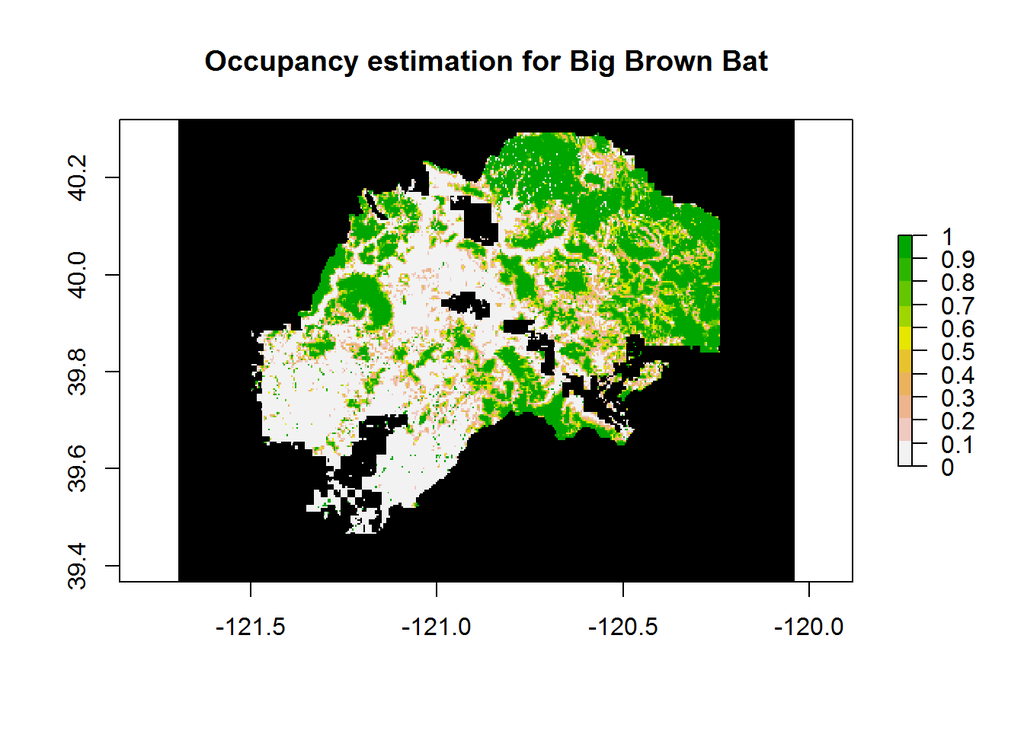

Statistical models

|  | **Model 1** | **Model 2** | **Model 3** | **Model 4** | **Model 5** | **Model 6** | **Model 7** | **Model 8** |
| --- | --- | --- | --- | --- | --- | --- | --- | --- |
| psi(Int) | -364.77 | -684.80 | -275.47 | -1023.48 | -547.15 | -651.14 | -306.64 | -546.29 |
|  | (214.21) | (509.30) | (170.51) | (668.02) | (398.96) | (617.36) | (159.77) | (359.61) |
| psi(Altitude) | 3.08* | 6.08 | 1.95 | 6.11 | 3.75 | 4.30 | 2.82* | 3.74* |
|  | (1.46) | (4.51) | (1.11) | (3.31) | (2.36) | (3.49) | (1.32) | (1.71) |
| psi(Burn.intensity.Canopy) | 2.98* | 3.23 | 1.94 | 4.73* | 3.12* | 3.31 | 2.78* | 3.36* |
|  | (1.38) | (1.66) | (1.12) | (2.28) | (1.46) | (1.70) | (1.25) | (1.48) |
| psi(Distance.to.road) | 2.00 | 3.17 | 1.82 | 2.17 |  | 2.01 | 1.85 | 2.00 |
|  | (1.21) | (1.82) | (0.98) | (1.43) |  | (1.37) | (1.17) | (1.28) |
| psi(Distance.to.water) | -671.72 | -1261.32 | -506.54 | -1884.91 | -1006.38 | -1197.95 | -564.71 | -1005.99 |
|  | (394.60) | (939.50) | (314.19) | (1230.50) | (734.37) | (1135.25) | (294.29) | (662.43) |
| psi(I(Distance.to.water^2)) | 372.31 | 698.52 | 280.81 | 1044.40 | 557.75 | 663.88 | 313.07 | 557.32 |
|  | (218.47) | (520.12) | (173.94) | (681.59) | (406.87) | (629.18) | (163.01) | (366.64) |
| psi(Existing.vegetation) | 1.62 |  | 1.38 | 2.81 | 1.60 | 2.07 | 1.46 | 2.04 |
|  | (0.96) |  | (0.76) | (1.81) | (1.13) | (1.38) | (0.89) | (1.16) |
| p(Int) | -0.05 | -0.21 | 0.14 | -0.10 | -0.14 | -0.11 | -0.17 | -0.05 |
|  | (0.29) | (0.27) | (0.34) | (0.29) | (0.28) | (0.31) | (0.27) | (0.29) |
| p(Julian) | 0.59 | 0.84** |  | 0.68* | 0.69* | 0.66 | 0.63* | 0.57 |
|  | (0.33) | (0.29) |  | (0.31) | (0.33) | (0.37) | (0.31) | (0.32) |
| p(Meanhum) | -0.54* | -0.51* | -0.67* |  | -0.50 | -0.51 |  | -0.52* |
|  | (0.27) | (0.26) | (0.29) |  | (0.26) | (0.27) |  | (0.26) |
| psi(I(Existing.vegetation^2)) |  | 1.17 |  |  |  |  |  |  |
|  |  | (1.16) |  |  |  |  |  |  |
| p(Meantemp) |  |  |  | 0.27 |  |  |  |  |
|  |  |  |  | (0.29) |  |  |  |  |
| psi(I(Distance.to.road^2)) |  |  |  |  | 0.92 |  |  |  |
|  |  |  |  |  | (1.31) |  |  |  |
| psi(I(Burn.intensity.Canopy^2)) |  |  |  |  |  | 0.81 |  |  |
|  |  |  |  |  |  | (1.87) |  |  |
| psi(Fire_edge) |  |  |  |  |  |  |  | -0.59 |
|  |  |  |  |  |  |  |  | (0.83) |
| Log Likelihood | -47.95 | -48.10 | -49.94 | -48.66 | -48.84 | -47.22 | -50.48 | -47.23 |
| AICc | 121.69 | 121.98 | 122.49 | 123.12 | 123.46 | 123.57 | 123.58 | 123.59 |
| Delta | 0.00 | 0.30 | 0.81 | 1.43 | 1.77 | 1.88 | 1.90 | 1.91 |
| Weight | 0.22 | 0.19 | 0.15 | 0.11 | 0.09 | 0.09 | 0.08 | 0.08 |
| Num. obs. | 49 | 49 | 49 | 49 | 49 | 49 | 49 | 49 |
| p < 0.001, p < 0.01, p < 0.05 |  |  |  |  |  |  |  |  |

## silver-haired bat (*Lasionycteris noctivagans*)

[output not shown]

[output cut: 53 more lines]

[output not shown]

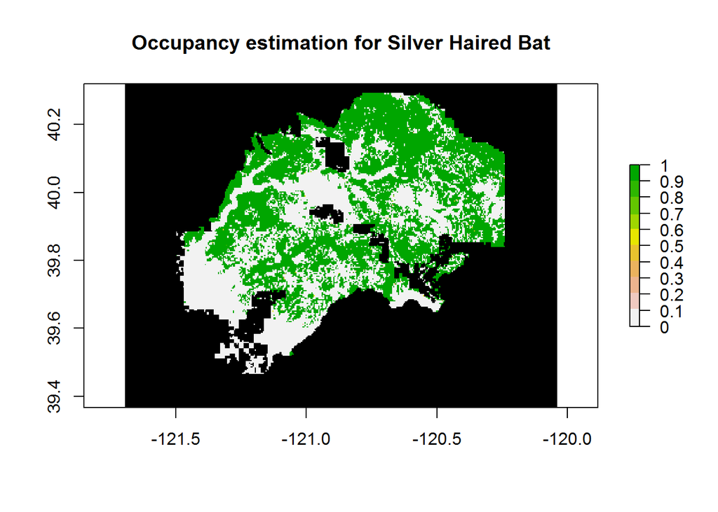

Statistical models

|  | **Model 1** | **Model 2** | **Model 3** | **Model 4** | **Model 5** |
| --- | --- | --- | --- | --- | --- |
| psi(Int) | 222.86 | 109.26 | 154.44 | 42.56 | 251.26 |
|  | (2617.39) | (1554.70) | (1143.36) | (42.41) | (3494.60) |
| psi(Altitude) | 228.64 | 161.82 | 177.34 | 61.58 | 314.40 |
|  | (3589.52) | (738.26) | (1262.93) | (36.18) | (2407.78) |
| psi(I(Altitude^2)) | -250.48 | -200.71 | -192.23 | -74.71 | -422.13 |
|  | (3655.03) | (959.56) | (1320.31) | (50.95) | (3186.27) |
| psi(Burn.intensity.Canopy) | 311.03 | 208.17 | 229.77 | 81.22 | 426.82 |
|  | (5687.49) | (1048.16) | (1249.37) | (60.32) | (3511.61) |
| psi(I(Burn.intensity.Canopy^2)) | -233.00 | -148.55 | -178.80 | -59.77 | -313.95 |
|  | (3912.77) | (747.01) | (1566.32) | (49.78) | (2605.84) |
| psi(Distance.to.road) | 62.66 | 80.62 | 41.01 | 20.87 | 64.18 |
|  | (1327.45) | (5038.44) | (221.28) | (37.32) | (6468.94) |
| psi(I(Distance.to.road^2)) | 201.30 | 158.10 | 152.29 | 52.73 | 394.64 |
|  | (3931.23) | (12929.38) | (1001.44) | (68.47) | (15186.19) |
| psi(I(Distance.to.water^2)) | -27.11 | -13.14 |  |  |  |
|  | (569.84) | (107.93) |  |  |  |
| psi(Existing.vegetation) | -123.52 | -103.04 | -90.90 | -39.60 | -209.26 |
|  | (2625.65) | (536.16) | (583.55) | (27.98) | (1705.01) |
| psi(I(Existing.vegetation^2)) | 242.39 | 206.07 | 176.54 | 73.57 | 350.46 |
|  | (4818.50) | (1215.44) | (1063.45) | (59.79) | (2502.72) |
| psi(I(Fire_edge^2)) | -43.45 |  | -29.21 |  |  |
|  | (783.14) |  | (258.70) |  |  |
| p(Int) | 0.36 | 0.36 | 0.36 | 0.36 | 0.28 |
|  | (0.22) | (0.22) | (0.22) | (0.22) | (0.22) |
| psi(Fire_edge) |  | -59.84 |  | -17.29 | -45.19 |
|  |  | (984.80) |  | (72.73) | (120.79) |
| psi(Distance.to.water) |  |  | -38.28 | -10.54 |  |
|  |  |  | (288.45) | (15.91) |  |
| Log Likelihood | -57.59 | -57.59 | -57.60 | -57.94 | -60.32 |
| AICc | 147.85 | 147.85 | 147.87 | 148.55 | 149.78 |
| Delta | 0.00 | 0.00 | 0.02 | 0.70 | 1.93 |
| Weight | 0.25 | 0.25 | 0.24 | 0.17 | 0.09 |
| Num. obs. | 49 | 49 | 49 | 49 | 49 |
| p < 0.001, p < 0.01, p < 0.05 |  |  |  |  |  |

## Brazilian free-tailed bat (*Tadarida brasiliensis*)

[output not shown]

[output cut: 53 more lines]

[output not shown]

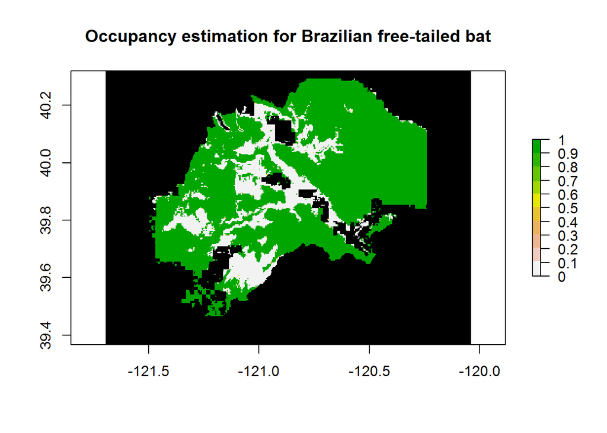

Statistical models

|  | **Model 1** | **Model 2** | **Model 3** |
| --- | --- | --- | --- |
| psi(Int) | 41.31 | 73.50 | 41.74 |
|  | (31.59) | (67.73) | (38.91) |
| psi(Altitude) | 356.63 | 267.80 | 347.05 |
|  | (362.22) | (247.31) | (314.46) |
| psi(I(Altitude^2)) | 308.46 | 205.99 | 301.78 |
|  | (320.53) | (191.76) | (278.41) |
| psi(Burn.intensity.Canopy) | 94.88 | 15.15 | 93.59 |
|  | (80.98) | (15.54) | (84.68) |
| psi(I(Existing.vegetation^2)) | 38.69 |  | 37.16 |
|  | (37.49) |  | (32.46) |
| p(Int) | 0.42* | 0.32 | 0.38 |
|  | (0.20) | (0.20) | (0.20) |
| p(Julian) | -0.34 |  |  |
|  | (0.20) |  |  |
| p(sdtemp) | 0.38 | 0.51* | 0.46* |
|  | (0.22) | (0.22) | (0.22) |
| p(Meantemp) |  | -0.28 |  |
|  |  | (0.20) |  |
| p(Meanhum) |  |  | 0.24 |
|  |  |  | (0.19) |
| Log Likelihood | -74.58 | -76.69 | -75.28 |
| AICc | 168.76 | 170.12 | 170.15 |
| Delta | 0.00 | 1.36 | 1.39 |
| Weight | 0.50 | 0.25 | 0.25 |
| Num. obs. | 49 | 49 | 49 |
| p < 0.001, p < 0.01, p < 0.05 |  |  |  |

## hoary bat (*Lasiurus cinereus*)

[output not shown]

[output cut: 53 more lines]

[output not shown]

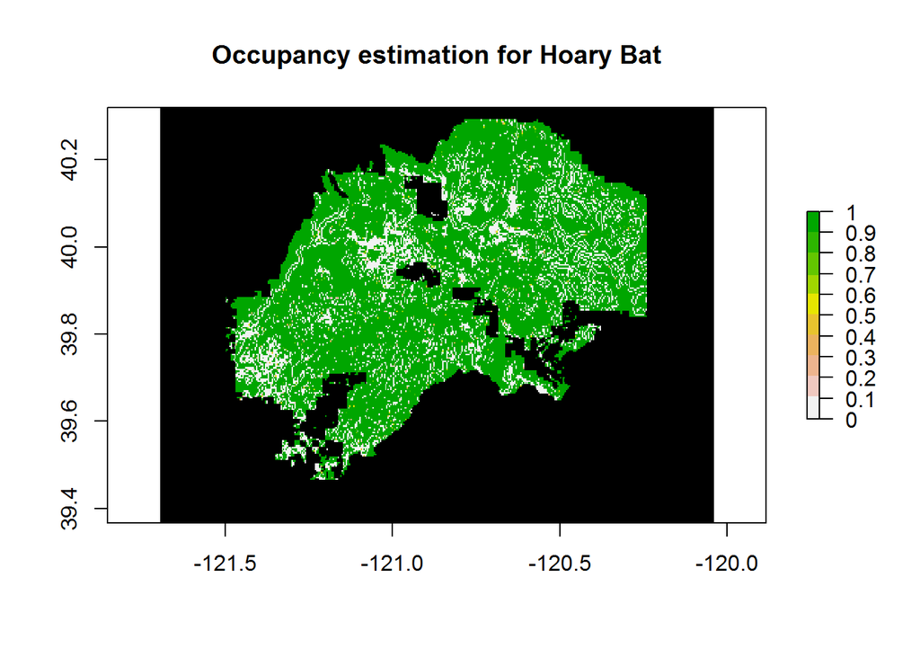

Statistical models

|  | **Model 1** | **Model 2** | **Model 3** | **Model 4** | **Model 5** | **Model 6** | **Model 7** | **Model 8** | **Model 9** | **Model 10** | **Model 11** | **Model 12** | **Model 13** | **Model 14** | **Model 15** | **Model 16** | **Model 17** | **Model 18** |
| --- | --- | --- | --- | --- | --- | --- | --- | --- | --- | --- | --- | --- | --- | --- | --- | --- | --- | --- |
| psi(Int) | -49.22 | 37.86 | 31.71 | 70.27 | -112.49 | 45.56 | 237.39 | 53.89 | 159.28 | -20.48 | 30.10 | 73.42 | -41.38 | 32.17 | 44.58 | 3.53 | 50.03 | 50.08 |
|  | (3047.68) | (39.87) | (4677.68) | (6051.43) | (3381.80) | (123.96) | (23406.22) | (244.08) | (7525.50) |  | (28.52) | (4087.12) | (31.25) |  | (5306.00) | (5884.21) | (140.60) | (334.14) |
| psi(I(Altitude^2)) | -5.56 |  | -4.07 |  |  |  |  |  |  |  |  |  |  |  |  |  |  |  |
|  | (8.50) |  | (3.72) |  |  |  |  |  |  |  |  |  |  |  |  |  |  |  |
| psi(Burn.intensity.Canopy) | 10.19 | 60.27 | 7.44 | 10.22 | 15.43 | 76.40 | 26.75 | 87.10 | 10.73 | 5.40 | 48.39 |  | 10.65 | 154.03 | 24.16 | 25.30 | 72.75 | 82.02 |
|  | (13.80) | (59.55) | (6.49) | (12.28) | (12.77) | (266.38) | (31.31) | (465.81) | (8.25) | (3.79) | (41.78) |  | (7.98) |  | (194.90) | (598.72) | (233.53) | (474.12) |
| psi(I(Distance.to.road^2)) | 300.96 | 77.92 | 218.35 | 297.21 | 578.35 | 97.13 | 1026.62 | 110.25 | 402.37 | 155.31 | 62.98 | 982.33 | 399.71 | 1004.13 | 75.05 | 64.89 | 95.67 | 107.15 |
|  | (356.50) | (76.83) | (162.31) | (333.45) | (444.18) | (237.07) | (1186.99) | (310.28) | (300.27) | (107.77) | (55.81) | (2595.32) | (292.27) | (1199.30) | (2049.42) | (162.81) | (167.40) | (342.64) |
| psi(I(Distance.to.water^2)) | 86.30 |  |  |  | 303.19 |  |  |  |  | 14.28 |  |  | 16.76 |  |  | 26.30 |  |  |
|  | (15938.96) |  |  |  | (17696.42) |  |  |  |  |  |  |  | (54.28) |  |  | (30761.51) |  |  |
| psi(Existing.vegetation) | -39.42 | -37.23 | -28.71 | -38.77 | -89.22 | -45.87 | -152.71 | -53.69 | -61.76 | -20.61 | -29.65 | -164.66 | -61.35 | -481.61 | -32.23 | -30.25 | -40.50 | -50.84 |
|  | (46.65) | (38.30) | (21.25) | (43.33) | (70.03) | (164.37) | (165.77) | (328.17) | (47.14) | (14.26) | (26.79) | (409.56) | (45.83) |  | (96.82) | (80.35) | (127.53) | (296.81) |
| p(Int) | -0.33 | -0.38 | -0.33 | -0.38 | -0.33 | -0.38 | -0.33 | -0.38 | -0.33 | -0.40* | -0.39* | -0.29 | -0.33 | -0.29 | -0.39 | -0.39 | -0.39 | -0.39 |
|  | (0.20) | (0.20) | (0.20) | (0.20) | (0.20) | (0.20) | (0.20) | (0.20) | (0.20) | (0.20) | (0.20) | (0.20) | (0.20) | (0.20) | (0.20) | (0.20) | (0.20) | (0.20) |
| p(Julian) | -0.40* | -0.52** | -0.40* | -0.39 | -0.40* | -0.44* | -0.53* | -0.54* | -0.40* | -0.39 | -0.51* | -0.52* | -0.53* | -0.52* | -0.50* | -0.50* | -0.50* | -0.50* |
|  | (0.20) | (0.20) | (0.20) | (0.20) | (0.20) | (0.21) | (0.21) | (0.21) | (0.20) | (0.20) | (0.21) | (0.20) | (0.21) | (0.20) | (0.20) | (0.20) | (0.20) | (0.20) |
| p(Meanhum) | 0.45* |  | 0.45* | 0.46* | 0.45* | 0.44* | 0.41* | 0.40* | 0.45* | 0.46* | 0.29 | 0.34 | 0.42* | 0.34 | 0.38 | 0.38 | 0.38 | 0.38 |
|  | (0.20) |  | (0.20) | (0.20) | (0.20) | (0.21) | (0.20) | (0.20) | (0.20) | (0.20) | (0.23) | (0.20) | (0.20) | (0.20) | (0.20) | (0.20) | (0.20) | (0.20) |
| p(sdtemp) | 0.34 |  | 0.34 | 0.32 | 0.34 | 0.27 |  |  | 0.34 | 0.30 |  |  |  |  |  |  |  |  |
|  | (0.22) |  | (0.22) | (0.22) | (0.22) | (0.22) |  |  | (0.22) | (0.22) |  |  |  |  |  |  |  |  |
| psi(Distance.to.road) |  | -72.39 |  |  |  | -87.69 |  | -101.56 |  |  | -57.82 | -185.57 |  | -861.24 | -58.86 | -56.38 | -91.61 | -99.62 |
|  |  | (74.49) |  |  |  | (169.16) |  | (191.17) |  |  | (53.77) | (416.50) |  |  | (802.52) | (159.25) | (174.23) | (235.53) |
| p(Meantemp) |  | -0.33 |  |  |  |  |  |  |  |  | -0.18 |  |  |  |  |  |  |  |
|  |  | (0.20) |  |  |  |  |  |  |  |  | (0.23) |  |  |  |  |  |  |  |
| psi(Distance.to.water) |  |  | 126.43 | 237.48 |  |  | 785.20 |  | 452.08 |  |  | 568.42 |  | 310.41 | 88.40 |  |  |  |
|  |  |  | (10699.53) | (13839.01) |  |  | (53528.78) |  | (17214.07) |  |  | (9409.74) |  |  | (12135.81) |  |  |  |
| psi(Altitude) |  |  |  |  | 20.63 |  | 35.37 |  | 14.29 |  |  | 46.51 | 14.17 | 117.42 |  |  |  |  |
|  |  |  |  |  | (16.27) |  | (38.74) |  | (10.89) |  |  | (120.92) | (10.58) |  |  |  |  |  |
| p(sdhum) |  |  |  |  |  |  | 0.31 | 0.21 |  |  |  |  | 0.31 |  |  |  |  |  |
|  |  |  |  |  |  |  | (0.23) | (0.23) |  |  |  |  | (0.23) |  |  |  |  |  |
| psi(I(Burn.intensity.Canopy^2)) |  |  |  |  |  |  |  |  |  |  |  | 68.62 |  | 128.56 |  |  |  |  |
|  |  |  |  |  |  |  |  |  |  |  |  | (161.43) |  |  |  |  |  |  |
| psi(I(Fire_edge^2)) |  |  |  |  |  |  |  |  |  |  |  | -7.79 |  |  |  |  |  |  |
|  |  |  |  |  |  |  |  |  |  |  |  | (18.88) |  |  |  |  |  |  |
| psi(I(Existing.vegetation^2)) |  |  |  |  |  |  |  |  |  |  |  |  |  |  |  |  | -6.68 |  |
|  |  |  |  |  |  |  |  |  |  |  |  |  |  |  |  |  | (81.64) |  |
| psi(Fire_edge) |  |  |  |  |  |  |  |  |  |  |  |  |  |  |  |  |  | -2.38 |
|  |  |  |  |  |  |  |  |  |  |  |  |  |  |  |  |  |  | (212.35) |
| Log Likelihood | -71.97 | -75.13 | -72.06 | -73.77 | -72.22 | -73.81 | -72.36 | -74.11 | -72.53 | -74.13 | -74.41 | -71.23 | -72.91 | -71.26 | -74.54 | -74.54 | -74.55 | -74.56 |
| AICc | 169.73 | 169.87 | 169.90 | 170.16 | 170.22 | 170.23 | 170.50 | 170.84 | 170.84 | 170.88 | 171.44 | 171.60 | 171.62 | 171.65 | 171.69 | 171.69 | 171.72 | 171.73 |
| Delta | 0.00 | 0.13 | 0.17 | 0.43 | 0.49 | 0.50 | 0.77 | 1.11 | 1.11 | 1.15 | 1.71 | 1.87 | 1.88 | 1.92 | 1.96 | 1.96 | 1.98 | 1.99 |
| Weight | 0.09 | 0.09 | 0.09 | 0.08 | 0.07 | 0.07 | 0.06 | 0.05 | 0.05 | 0.05 | 0.04 | 0.04 | 0.04 | 0.04 | 0.04 | 0.04 | 0.03 | 0.03 |
| Num. obs. | 49 | 49 | 49 | 49 | 49 | 49 | 49 | 49 | 49 | 49 | 49 | 49 | 49 | 49 | 49 | 49 | 49 | 49 |
| p < 0.001, p < 0.01, p < 0.05 |  |  |  |  |  |  |  |  |  |  |  |  |  |  |  |  |  |  |

## Spotted bat (*Euderma maculatum*)

[output not shown]

[output cut: 53 more lines]

[output not shown]

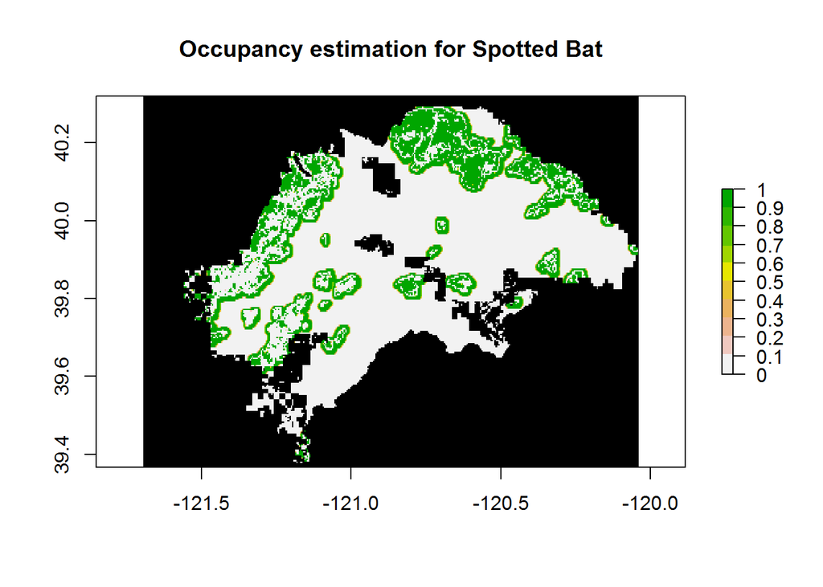

Statistical models

|  | **Model 1** | **Model 2** | **Model 3** | **Model 4** | **Model 5** | **Model 6** | **Model 7** | **Model 8** | **Model 9** | **Model 10** | **Model 11** | **Model 12** | **Model 13** | **Model 14** | **Model 15** | **Model 16** | **Model 17** | **Model 18** | **Model 19** | **Model 20** | **Model 21** |
| --- | --- | --- | --- | --- | --- | --- | --- | --- | --- | --- | --- | --- | --- | --- | --- | --- | --- | --- | --- | --- | --- |
| psi(Int) | -68.52 | -4.12 | -41.17 | -46.18 | -108.42 | -7.78 | -59.11 | -7.70 | -37.74 | -49.85 | -18.04 | -32.75 | -92.43 | -10.56 | -43.82 | -31.33 | -39.90 | -55.88 | -46.79 | 5.57 | -13.66 |
|  | (138.74) | (28.24) | (43.06) | (150.96) |  | (18.28) | (44.81) | (42.80) | (33.80) | (67.87) | (32.76) | (49.68) | (87.00) | (13.69) | (44.49) | (76.69) | (42.51) | (88.78) | (68.58) | (112.28) | (23.02) |
| psi(I(Burn.intensity.Canopy^2)) | 61.58 |  |  |  | 117.44 |  |  |  |  | 40.72 |  |  | 64.08 |  |  | 27.32 |  | 62.94 | 32.34 |  |  |
|  | (124.19) |  |  |  |  |  |  |  |  | (77.26) |  |  | (60.97) |  |  | (65.24) |  | (97.15) | (46.36) |  |  |
| psi(Fire_edge) | -54.02 |  | -34.99 | -47.83 | -69.16 | -30.13 | -38.99 |  | -31.04 | -27.61 |  | -23.61 | -47.98 |  | -26.09 | -21.09 | -32.99 | -26.00 | -36.43 |  |  |
|  | (116.02) |  | (37.72) | (68.80) | (121.93) | (39.46) | (30.25) |  | (29.96) | (33.25) |  | (41.41) | (47.06) |  | (31.30) | (56.22) | (37.90) | (48.32) | (51.93) |  |  |
| p(Int) | -2.95*** | -2.65*** | -2.56** | -2.79*** | -2.73*** | -2.46*** | -1.64** | -2.39*** | -2.00*** | -2.77*** | -3.10*** | -3.04*** | -2.04*** | -2.75*** | -2.75*** | -2.80** | -2.15*** | -2.33*** | -2.78*** | -2.57*** | -3.01*** |
|  | (0.82) | (0.61) | (0.82) | (0.83) | (0.77) | (0.62) | (0.56) | (0.66) | (0.54) | (0.77) | (0.92) | (0.84) | (0.54) | (0.78) | (0.82) | (0.98) | (0.61) | (0.54) | (0.82) | (0.61) | (0.79) |
| p(Meanhum) | -1.26 |  | -1.11 | -1.28 | -1.21 |  |  |  |  | -1.24 | -0.84 | -1.14 |  | -1.24 | -1.16 | -1.25 |  |  | -1.25 |  | -1.06 |
|  | (0.70) |  | (0.72) | (0.75) | (0.66) |  |  |  |  | (0.67) | (0.80) | (0.73) |  | (0.71) | (0.74) | (0.83) |  |  | (0.68) |  | (0.68) |
| psi(I(Distance.to.road^2)) |  | 68.35 | 16.88 | 182.81 | -13.02 | 48.43 | 24.21 | 53.97 | 14.84 |  | 111.35 | 64.74 |  | 61.58 | 78.66 |  | 16.34 |  |  | 63.47 | 73.39 |
|  |  | (109.58) | (33.72) | (466.08) | (258.53) | (59.97) | (18.96) | (196.47) | (33.55) |  | (167.76) | (92.47) |  | (66.10) | (79.57) |  | (39.21) |  |  | (93.62) | (120.49) |
| psi(I(Existing.vegetation^2)) |  | -24.44 |  | -56.65 |  | -33.50 |  | -25.14 |  |  | -25.15 |  |  | -28.60 |  |  |  |  |  | -30.51 | -14.24 |
|  |  | (37.80) |  | (80.93) |  | (39.37) |  | (95.55) |  |  | (38.52) |  |  | (32.33) |  |  |  |  |  | (89.24) | (25.64) |
| p(sdtemp) |  | 1.46* |  |  |  | 1.59* |  | 1.41* |  |  | 1.19 |  |  |  |  |  | 0.82 |  |  | 1.61* |  |
|  |  | (0.67) |  |  |  | (0.75) |  | (0.68) |  |  | (0.72) |  |  |  |  |  | (0.56) |  |  | (0.73) |  |
| psi(Existing.vegetation) |  |  | -25.23 |  |  |  | -30.90 |  | -24.06 | -13.27 |  |  | -32.80 |  |  |  | -25.37 |  |  |  |  |
|  |  |  | (30.81) |  |  |  | (22.97) |  | (24.74) |  |  |  | (30.59) |  |  |  | (29.50) |  |  |  |  |
| psi(Distance.to.road) |  |  |  |  |  |  | -15.57 |  |  |  |  |  |  |  |  | -5.99 |  |  |  |  |  |
|  |  |  |  |  |  |  | (12.43) |  |  |  |  |  |  |  |  | (36.98) |  |  |  |  |  |
| psi(Altitude) |  |  |  |  |  |  |  | 7.11 |  |  |  |  |  | 9.18 | 6.48 |  |  |  | 7.23 |  |  |
|  |  |  |  |  |  |  |  | (29.70) |  |  |  |  |  | (11.45) | (6.94) |  |  |  | (10.09) |  |  |
| psi(I(Fire_edge^2)) |  |  |  |  |  |  |  |  |  |  |  |  |  |  |  |  |  |  |  | -12.66 |  |
|  |  |  |  |  |  |  |  |  |  |  |  |  |  |  |  |  |  |  |  | (167.44) |  |
| Log Likelihood | -11.74 | -11.89 | -10.78 | -11.00 | -11.01 | -11.08 | -11.09 | -11.10 | -12.43 | -11.13 | -11.19 | -12.49 | -12.52 | -11.23 | -11.23 | -11.25 | -11.27 | -13.82 | -11.31 | -11.33 | -12.64 |
| AICc | 34.88 | 35.17 | 35.56 | 35.99 | 36.02 | 36.15 | 36.17 | 36.21 | 36.25 | 36.25 | 36.37 | 36.38 | 36.43 | 36.45 | 36.46 | 36.49 | 36.53 | 36.55 | 36.61 | 36.66 | 36.67 |
| Delta | 0.00 | 0.29 | 0.68 | 1.12 | 1.14 | 1.28 | 1.29 | 1.33 | 1.37 | 1.38 | 1.50 | 1.51 | 1.55 | 1.57 | 1.59 | 1.62 | 1.66 | 1.68 | 1.74 | 1.79 | 1.79 |
| Weight | 0.09 | 0.08 | 0.06 | 0.05 | 0.05 | 0.05 | 0.05 | 0.05 | 0.05 | 0.05 | 0.04 | 0.04 | 0.04 | 0.04 | 0.04 | 0.04 | 0.04 | 0.04 | 0.04 | 0.04 | 0.04 |
| Num. obs. | 49 | 49 | 49 | 49 | 49 | 49 | 49 | 49 | 49 | 49 | 49 | 49 | 49 | 49 | 49 | 49 | 49 | 49 | 49 | 49 | 49 |
| p < 0.001, p < 0.01, p < 0.05 |  |  |  |  |  |  |  |  |  |  |  |  |  |  |  |  |  |  |  |  |  |

## western mastiff bat (*Eumops perotis*)

[output not shown]

[output cut: 53 more lines]

[output not shown]

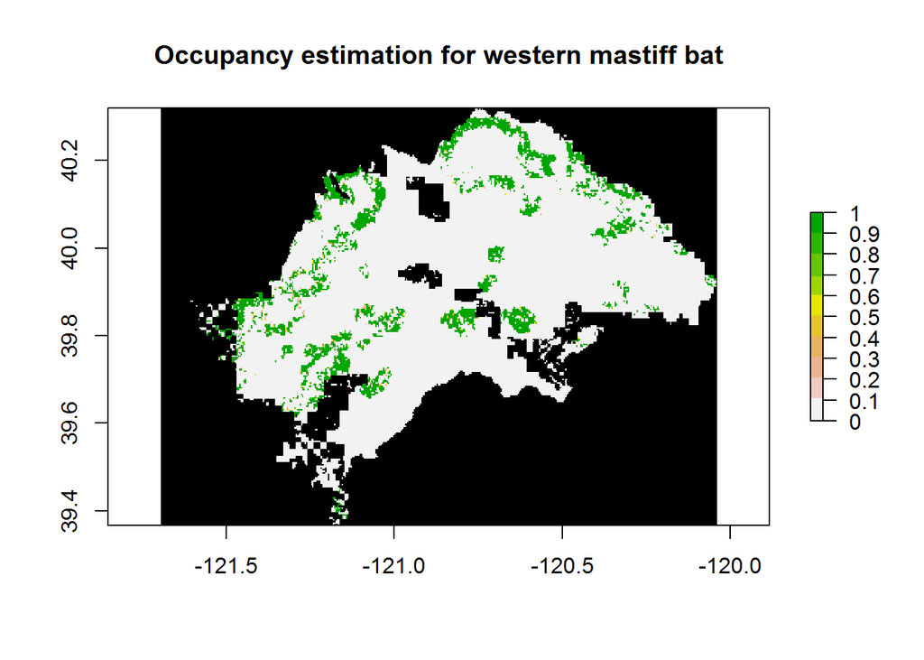

Statistical models

|  | **Model 1** | **Model 2** | **Model 3** | **Model 4** | **Model 5** | **Model 6** |
| --- | --- | --- | --- | --- | --- | --- |
| psi(Int) | -97.46 | -78.68 | -61.83 | -52.95 | -154.74 | -118.83 |
|  |  | (13743.89) | (50.62) | (41.83) | (179.35) | (24249.76) |
| psi(I(Distance.to.water^2)) | -28.20 |  |  |  |  | -118.15 |
|  |  |  |  |  |  | (126861.43) |
| psi(Existing.vegetation) | -50.83 | -32.97 | -30.67 | -16.42 | -76.96 | -71.08 |
|  | (51.63) | (27.40) | (26.41) | (14.09) | (92.66) | (80.89) |
| psi(Fire_edge) | -103.73 | -68.21 | -62.45 | -50.25 | -155.68 | -141.78 |
|  | (98.98) | (54.25) | (50.13) | (41.39) | (180.80) | (150.62) |
| p(Int) | -0.42 | -0.44 | -0.72 | -0.45 | -0.66 | -0.38 |
|  | (0.53) | (0.54) | (0.51) | (0.54) | (0.51) | (0.54) |
| psi(Distance.to.water) |  | -25.78 |  |  |  |  |
|  |  | (31436.33) |  |  |  |  |
| psi(Burn.intensity.Canopy) |  |  |  | 9.64 |  |  |
|  |  |  |  | (8.27) |  |  |
| p(sdhum) |  |  |  |  | 0.49 | 0.36 |
|  |  |  |  |  | (0.57) | (0.55) |
| Log Likelihood | -10.32 | -10.59 | -11.99 | -10.98 | -11.14 | -9.97 |
| AICc | 32.04 | 32.57 | 32.88 | 33.35 | 33.68 | 33.93 |
| Delta | 0.00 | 0.52 | 0.84 | 1.31 | 1.64 | 1.89 |
| Weight | 0.26 | 0.20 | 0.17 | 0.14 | 0.12 | 0.10 |
| Num. obs. | 49 | 49 | 49 | 49 | 49 | 49 |
| p < 0.001, p < 0.01, p < 0.05 |  |  |  |  |  |  |

# Relationships between different species of Bats

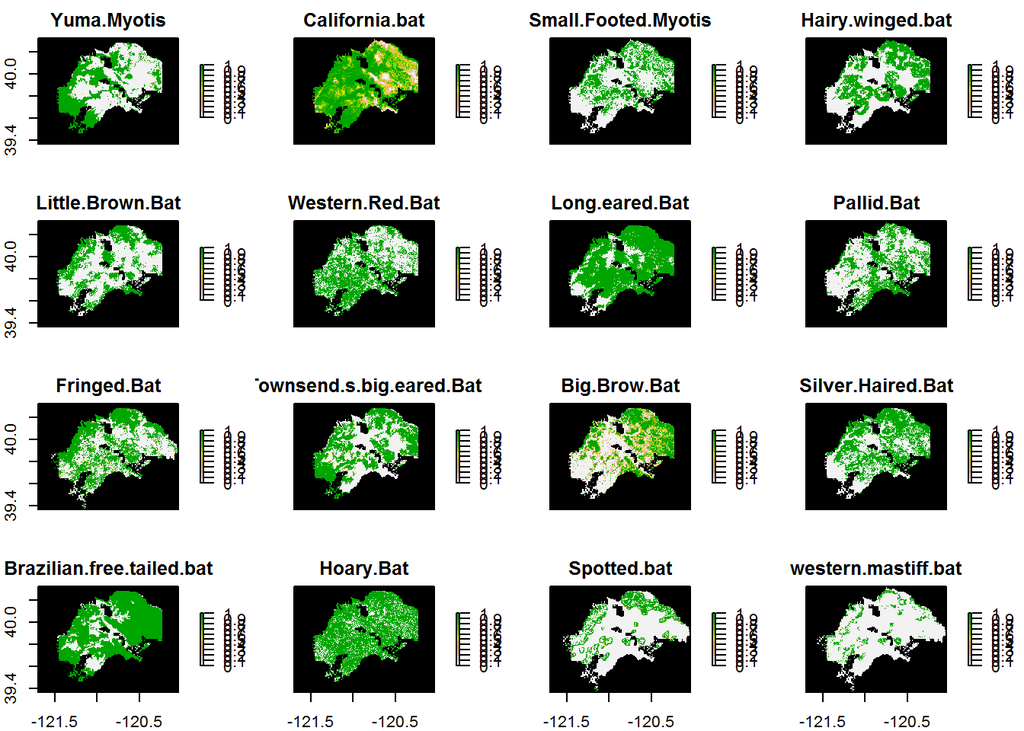

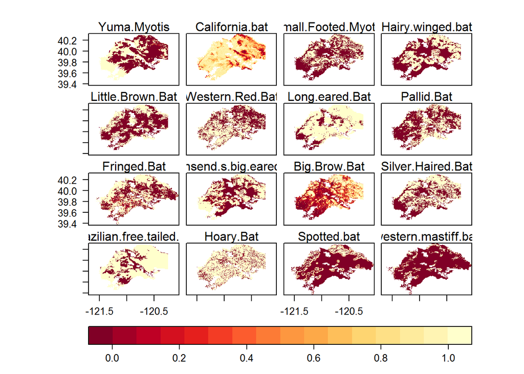

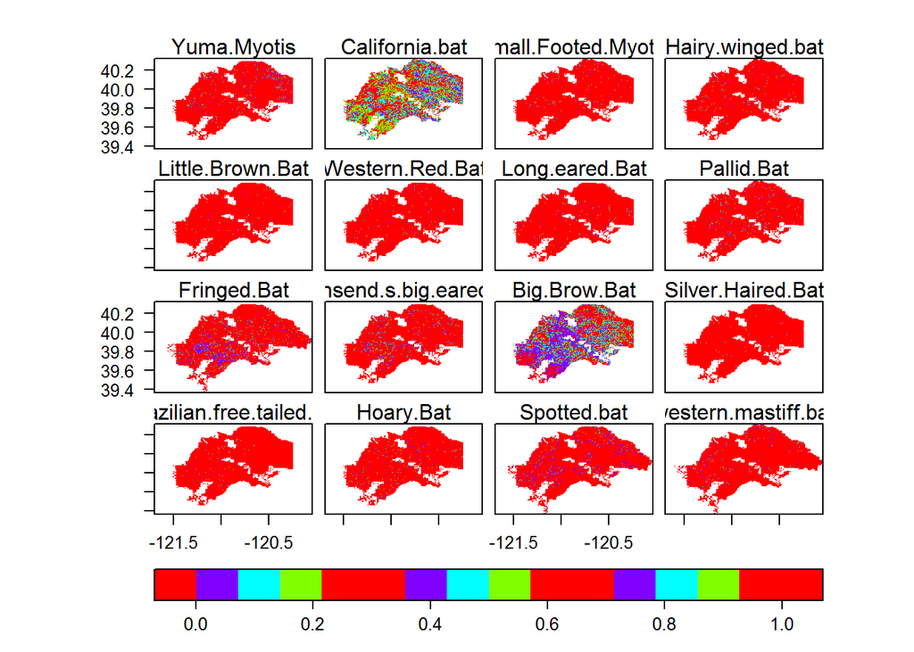

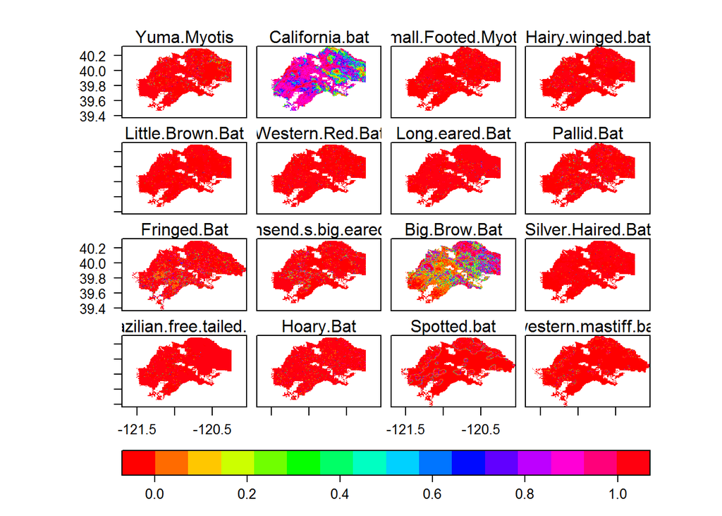

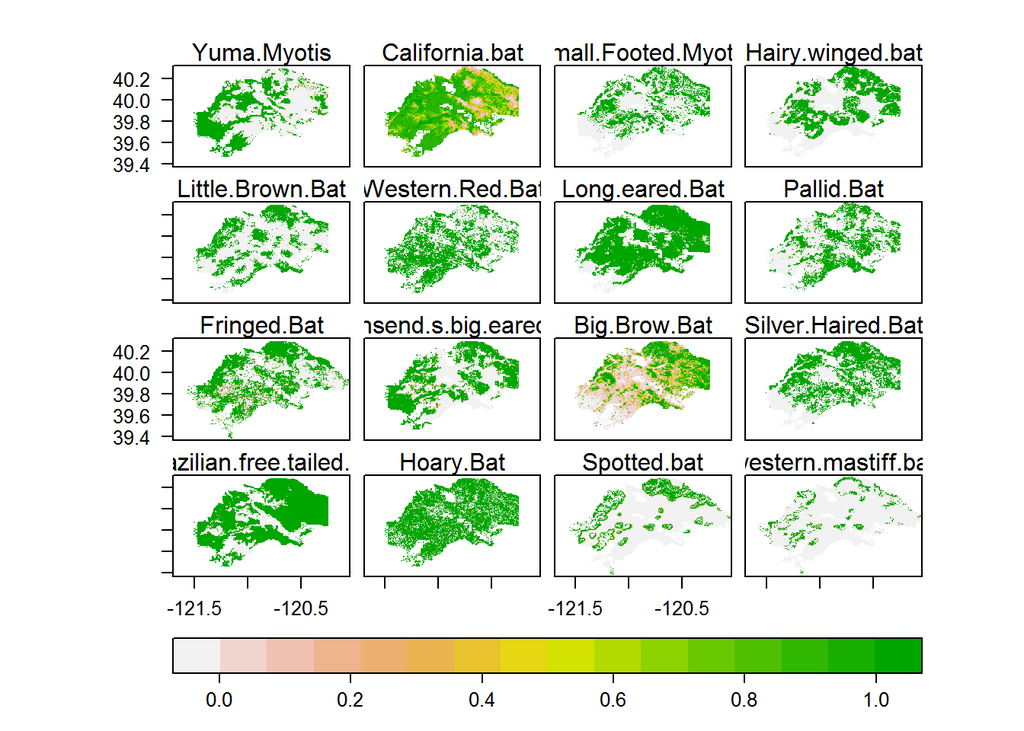

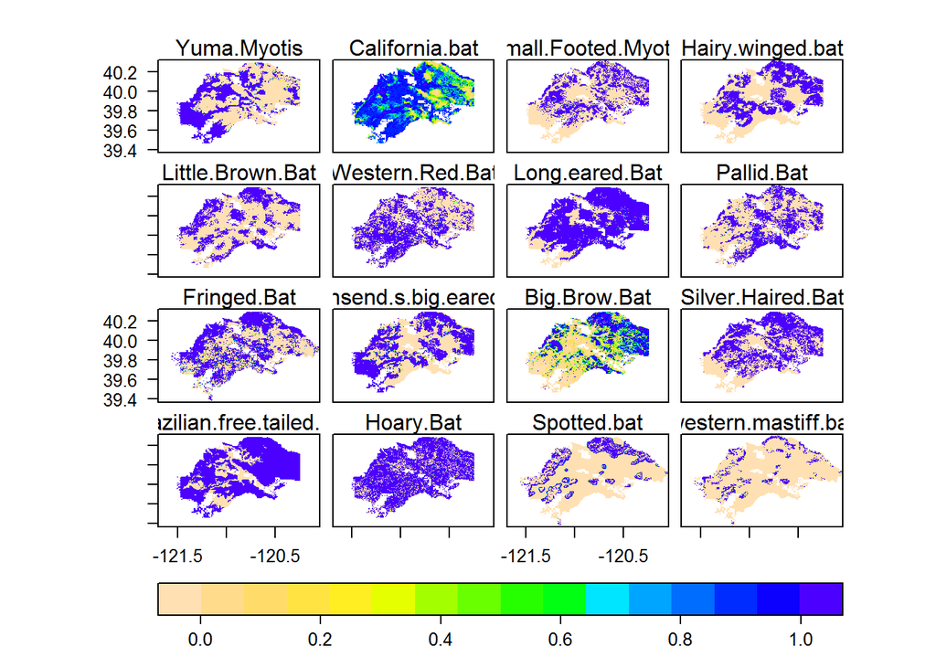

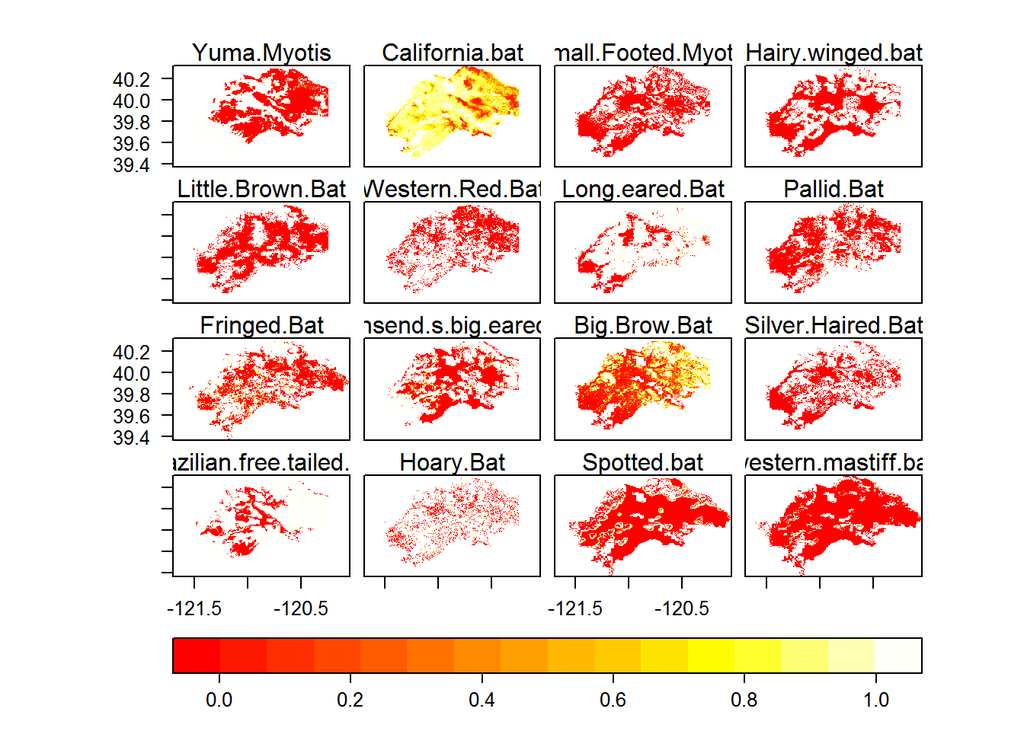

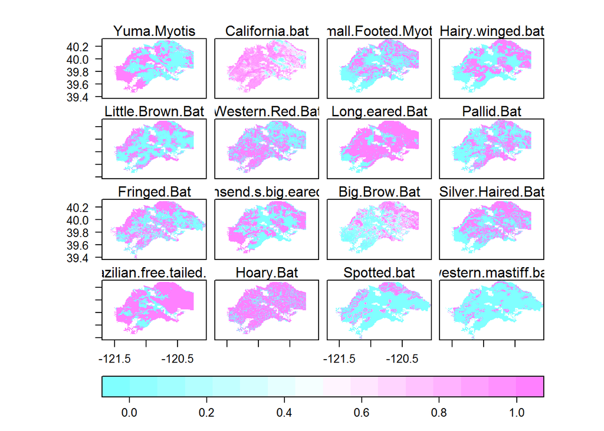

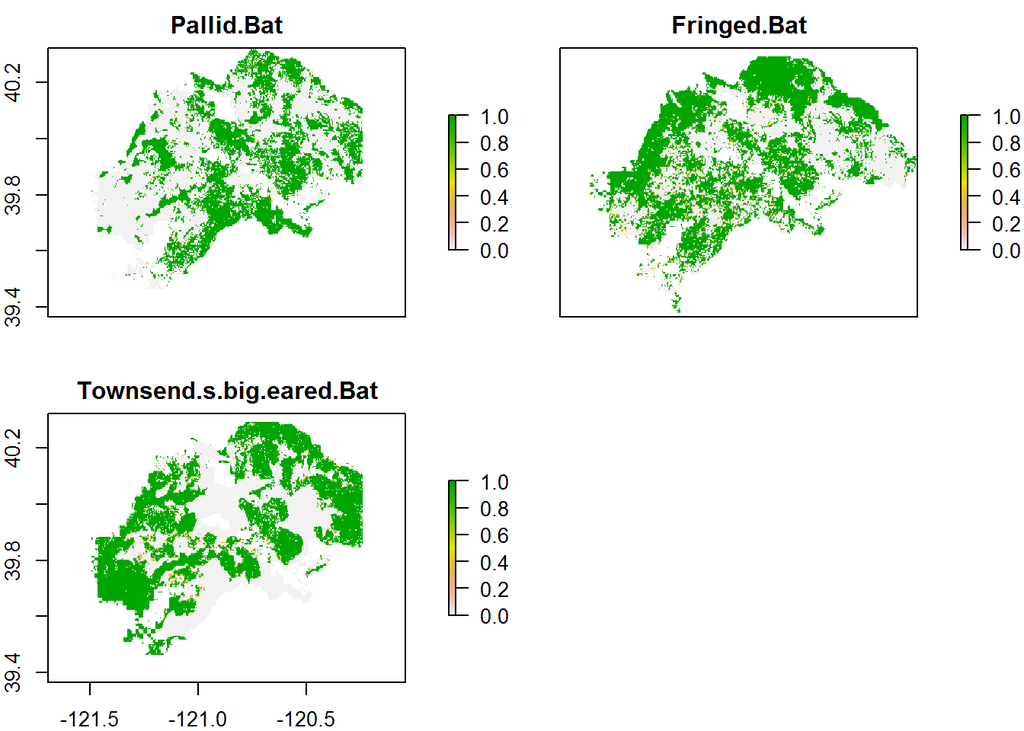

```r
desition <- stack(Occu1.layer.AnPa2$layer.1, Occu1.layer.MyTh2$layer.1, Occu1.layer.CoTo2$layer.1)
names(desition) <- c("Pallid Bat", "Fringed Bat", "Townsend's big-eared Bat")
plot(desition)
```

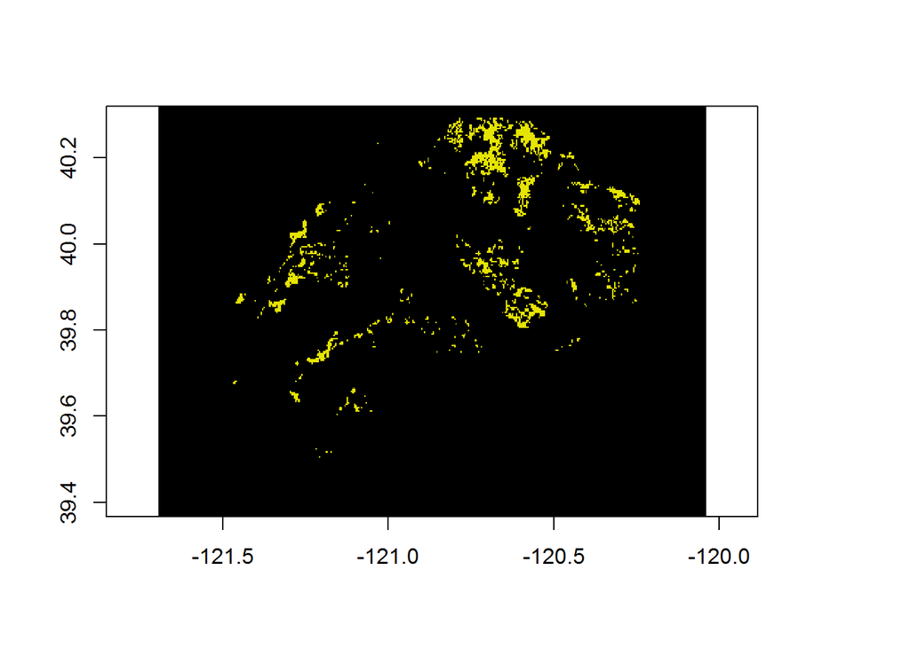

```r
nths <- quantile(desition, 0.65)
desition <- unstack(desition)
rc<-list()
for (i in 1:length(nths)){
m <- c(-Inf, nths[i], NA,  nths[i], Inf, 1)
rclmat <- matrix(m, ncol=3, byrow=TRUE)
    rc[[i]]<-reclassify(desition[[i]] , rcl = rclmat)
  }
rc<- stack(unlist(rc))
priority.area <- prod(rc)
plot(priority.area, colNA="black", legend = FALSE)
```

```r
KML(priority.area, file='priority_area.kml', overwrite = TRUE)
Fire_edge <- readGDAL("~/new_bats/Rnew_bats/Bats_data_products/fire_edge.asc")
```

~/new_bats/Rnew_bats/Bats_data_products/fire_edge.asc has GDAL driver AAIGrid and has 250 rows and 434 columns

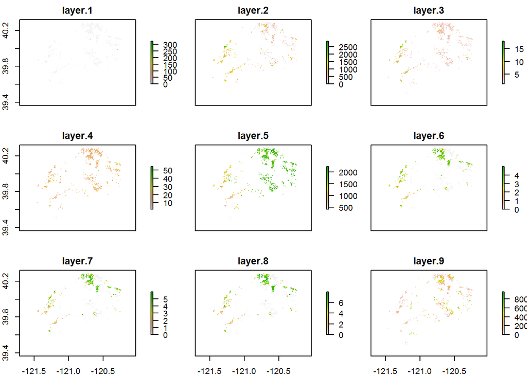

```r
Fire_edge <- raster(Fire_edge)
Predictors <-stack(riverdist.r, roaddist.r, Vegetation_existing,  FireReturnAll, topo, bs,bc, bb, Fire_edge)
names(Predictors)<-c("Distance to water", "Distance to road","Existing vegetation","Fire Interval","Altitude", "Burn intensity soil","Burn intensity Canopy", "Burn intensity basal", "Fire_edge")

Predictors2<- Predictors*priority.area


plot(Predictors2)
```

```r
Predictors2 <-as.data.frame(Predictors2)

colnames(Predictors2) <- c("Distance.to.water", "Distance.to.road","Existing.vegetation","Fire.Interval","Altitude", "Burn.intensity.soil","Burn.intensity.Canopy", "Burn.intensity.basal", "Fire.edge")

summary(Predictors2)
```

Distance.to.water Distance.to.road Existing.vegetation Fire.Interval  
Min. : 0.0 Min. : 0.0 Min. : 1.00 Min. : 1.57  
1st Qu.: 0.0 1st Qu.: 0.0 1st Qu.: 3.00 1st Qu.:13.98  
Median : 0.0 Median : 424.2 Median : 3.00 Median :16.00  
Mean : 0.7 Mean : 530.1 Mean : 3.94 Mean :16.21  
3rd Qu.: 0.0 3rd Qu.: 908.6 3rd Qu.: 3.66 3rd Qu.:16.00  
Max. :326.3 Max. :3109.8 Max. :18.00 Max. :55.00  
NA’s :105709 NA’s :105709 NA’s :105709 NA’s :105875  
Altitude Burn.intensity.soil Burn.intensity.Canopy Min. : 396.6 Min. :0.00 Min. :0.00  
1st Qu.:1703.1 1st Qu.:0.00 1st Qu.:0.00  
Median :1871.6 Median :1.92 Median :1.45  
Mean :1727.9 Mean :1.71 Mean :1.99  
3rd Qu.:1949.6 3rd Qu.:3.44 3rd Qu.:4.28  
Max. :2370.1 Max. :5.00 Max. :6.00  
NA’s :105709 NA’s :105709 NA’s :105709  
Burn.intensity.basal Fire.edge  
Min. :0.00 Min. : 0.0  
1st Qu.:0.00 1st Qu.: 848.4  
Median :1.67 Median :1817.6  
Mean :2.68 Mean :2203.7  
3rd Qu.:5.79 3rd Qu.:3349.7  
Max. :8.00 Max. :9612.6  
NA’s :105709 NA’s :105709

```r
stargazer(Predictors2, type = "text", out = "common.txt")
```

```r
stargazer(Predictors2, type = "html")
```

| Statistic | N | Mean | St. Dev. | Min | Max |
| --- | --- | --- | --- | --- | --- |
| Distance.to.water | 2,791 | 0.699 | 15.071 | 0.000 | 326.259 |
| Distance.to.road | 2,791 | 530.104 | 558.253 | 0.000 | 3,109.837 |
| Existing.vegetation | 2,791 | 3.942 | 2.457 | 1.000 | 18.000 |
| Fire.Interval | 2,625 | 16.214 | 4.765 | 1.574 | 55.000 |
| Altitude | 2,791 | 1,727.872 | 360.838 | 396.593 | 2,370.091 |
| Burn.intensity.soil | 2,791 | 1.714 | 1.670 | 0.000 | 5.000 |
| Burn.intensity.Canopy | 2,791 | 1.985 | 2.061 | 0.000 | 6.000 |
| Burn.intensity.basal | 2,791 | 2.685 | 2.845 | 0.000 | 8.000 |
| Fire.edge | 2,791 | 2,203.709 | 1,726.534 | 0.000 | 9,612.572 |